# BCR + GEX Integration Tutorial – Part 2: Seurat Analysis and Annotation

From Cell Ranger GEX output to an annotated B cell Seurat object

Nachi Nathan

2026-05-21

# Prerequisites

Before running this part, the following must be in place.

**Input files required**

| File | Where it comes from |
| --- | --- |
| `P1_LN_bcr_data.tsv` | Part 1 output, or download from Zenodo: https://zenodo.org/records/20324083 |
| `P1_PT_bcr_data.tsv` | Part 1 output, or download from Zenodo: https://zenodo.org/records/20324083 |
| `P1_LN_sample_filtered_feature_bc_matrix.h5` | Cell Ranger GEX output, or download from Zenodo: https://zenodo.org/records/20323951 |
| `P1_PT_sample_filtered_feature_bc_matrix.h5` | Cell Ranger GEX output, or download from Zenodo: https://zenodo.org/records/20323951 |

**R packages required**

```r
install.packages(c("dplyr", "ggplot2", "data.table", "tibble",
                   "viridis", "scales", "patchwork", "pheatmap"))
# Seurat v5
install.packages("Seurat")
# Optional but recommended for faster DEG computation
install.packages("devtools")
devtools::install_github("immunogenomics/presto")
```

**R version:** This tutorial was developed under R 4.3 with Seurat v5. Seurat v4 will not work with the `IntegrateLayers()` workflow used in Step 6.

# Overview

This part covers the complete single-cell GEX analysis pipeline, from loading raw count matrices through to a fully annotated Seurat object. It runs in sequence – each step feeds directly into the next – and produces a single output file at the end: `integrated_S7_annotated.rds`.

The steps are:

1. **GEX QC** – load `.h5` count matrices, inspect quality metrics, filter low-quality cells.
2. **Doublet removal** – keep only CD79A-positive cells and remove B cell / non-B cell doublets.
3. **Add BCR metadata** – join the BCR TSV from Part 1 to each Seurat object by barcode matching.
4. **Solo GEX analysis** – per-sample normalization, HVG selection (with IG/TCR gene exclusion), PCA, clustering, UMAP, BCR overlay.
5. **Integration** – RPCA batch correction across samples, joint UMAP, joint clustering.
6. **Cluster annotation** – DotPlot, BCR metadata, DEG analysis, final label assignment.

# Setup

Set these variables before running anything else. All paths downstream are derived from these.

```r
suppressPackageStartupMessages({
  library(Seurat)
  library(Matrix)
  library(dplyr)
  library(data.table)
  library(tibble)
  library(ggplot2)
  library(viridis)
  library(scales)
  library(patchwork)
  library(pheatmap)
})

# Root directory -- each sample has its own subfolder here
ROOT_DIR <- "C:/Users/natha/OneDrive/Documents/Immcantation/BCR_Tutorial/Github"

# RDS output directory -- all Seurat objects are written here
RDS_DIR <- file.path(ROOT_DIR, "RDS_Objects")
if (!dir.exists(RDS_DIR)) dir.create(RDS_DIR, recursive = TRUE)

# Sample definitions
samples <- list(
  P1_LN = list(
    sample_id  = "P1_LN",
    h5         = file.path(ROOT_DIR, "P1_LN/P1_LN_sample_filtered_feature_bc_matrix.h5"),
    bcr_tsv    = file.path(ROOT_DIR, "P1_LN/Output/P1_LN_bcr_data.tsv"),
    output_dir = RDS_DIR
  ),
  P1_PT = list(
    sample_id  = "P1_PT",
    h5         = file.path(ROOT_DIR, "P1_PT/P1_PT_sample_filtered_feature_bc_matrix.h5"),
    bcr_tsv    = file.path(ROOT_DIR, "P1_PT/Output/P1_PT_bcr_data.tsv"),
    output_dir = RDS_DIR
  )
)

message("Ready. Samples: ", paste(names(samples), collapse = ", "))
```

```
## Ready. Samples: P1_LN, P1_PT
```

# Step 2: GEX QC and Filtering

## 2.1 QC thresholds

The thresholds below are applied uniformly to all samples. Inspect the violin plots in section 2.3 carefully before accepting them for your own data – the right values depend on the tissue and library quality.

| Parameter | Value | What it removes |
| --- | --- | --- |
| `min_features` | 250 | Empty droplets with almost no detected genes |
| `max_features` | 6,500 | Likely doublets with abnormally high gene counts |
| `min_UMI` | 500 | Low-quality or empty droplets |
| `max_UMI` | 35,000 | Likely doublets with abnormally high UMI counts |
| `filter_mt` | 10% | Damaged or dying cells |

When a cell is damaged or dying, cytoplasmic mRNA leaks out while mitochondrial transcripts remain protected inside the organelle, producing a characteristic signature of high mt% alongside low gene and UMI counts. A threshold of 10% is appropriate for lymphoid tissue. For tumor samples with many metabolically active cells, a slightly higher threshold may be warranted – always inspect the distribution first.

```r
min_features   <- 250
max_features   <- 6500
min_UMI        <- 500
max_UMI        <- 35000
filter_mt      <- 10

mito_pattern   <- "^MT-"   # "^MT-" for human, "^mt-" for mouse
min_cells_gene <- 5        # genes detected in fewer cells than this are dropped
```

## 2.2 Load count matrices and create Seurat objects

We load the `.h5` count matrix for each sample and create a Seurat object. Mitochondrial percentage is calculated immediately after loading, before any filtering, so we have the full distribution to inspect.

We also suffix every barcode with the sample name at this stage. Cell Ranger barcodes are not unique across samples – both P1_LN and P1_PT contain cells called `ACGT...TGCA-1` – and adding the sample ID prevents collisions when samples are merged later. This matches the barcode suffixing done on the BCR side in Part 1.

```r
seurat_list <- list()

for (s in samples) {

  message("Loading: ", s$sample_id)

  if (!file.exists(s$h5)) {
    stop("H5 file not found for ", s$sample_id, ":\n  ", s$h5,
         "\nCheck that the path is correct.")
  }

  counts <- Read10X_h5(s$h5)
  if (is.list(counts)) counts <- counts[["Gene Expression"]]

  obj <- CreateSeuratObject(
    counts       = counts,
    project      = s$sample_id,
    min.cells    = min_cells_gene,
    min.features = 0
  )

  obj[["percent.mt"]] <- PercentageFeatureSet(obj, pattern = mito_pattern)
  obj <- RenameCells(obj, new.names = paste0(colnames(obj), "_", s$sample_id))

  message("  Cells: ", ncol(obj), " | Genes: ", nrow(obj))
  seurat_list[[s$sample_id]] <- obj
}
```

```
## Loading: P1_LN
```

```
##   Cells: 6061 | Genes: 18521
```

```
## Loading: P1_PT
```

```
##   Cells: 8067 | Genes: 19889
```

The two samples loaded as expected:

| Sample | Cells | Genes |
| --- | --- | --- |
| P1_LN | 6,061 | 18,521 |
| P1_PT | 8,067 | 19,889 |

P1_PT has more cells and a slightly larger detected transcriptome, consistent with the greater cellular complexity of tumor tissue.

## 2.3 Inspect QC metrics before filtering

Look at the violin plots carefully before proceeding. You are looking for a unimodal distribution of `nFeature_RNA` with a lower tail of empty droplets and possibly an upper tail of doublets; `percent.mt` clustered low with a tail of damaged cells; and a linear relationship in the UMI vs genes scatter, with cells falling well above the line being candidate doublets.

```r
for (s_id in names(seurat_list)) {

  obj <- seurat_list[[s_id]]

  print(
    VlnPlot(obj,
            features = c("nFeature_RNA", "nCount_RNA", "percent.mt"),
            pt.size  = 0.1,
            ncol     = 3) &
      ggplot2::labs(title = paste0(s_id, " -- QC metrics (pre-filter)"))
  )

  print(FeatureScatter(obj, feature1 = "nCount_RNA", feature2 = "percent.mt") +
    ggplot2::ggtitle(paste0(s_id, " -- UMI vs mt%")))

  print(FeatureScatter(obj, feature1 = "nCount_RNA", feature2 = "nFeature_RNA") +
    ggplot2::ggtitle(paste0(s_id, " -- UMI vs genes detected")))
}
```

[figure not shown]

```r
pre_stats <- lapply(names(seurat_list), function(s_id) {
  obj <- seurat_list[[s_id]]
  data.frame(
    Sample        = s_id,
    Cells         = ncol(obj),
    Median_genes  = median(obj$nFeature_RNA),
    Median_UMI    = median(obj$nCount_RNA),
    Median_mt_pct = round(median(obj$percent.mt), 2),
    Max_mt_pct    = round(max(obj$percent.mt), 2),
    Cells_mt_gt10 = sum(obj$percent.mt > 10),
    Cells_gene_hi = sum(obj$nFeature_RNA > max_features),
    Cells_gene_lo = sum(obj$nFeature_RNA < min_features),
    Cells_UMI_hi  = sum(obj$nCount_RNA > max_UMI),
    Cells_UMI_lo  = sum(obj$nCount_RNA < min_UMI)
  )
})
knitr::kable(do.call(rbind, pre_stats), caption = "QC summary before filtering")
```

QC summary before filtering

| Sample | Cells | Median_genes | Median_UMI | Median_mt_pct | Max_mt_pct | Cells_mt_gt10 | Cells_gene_hi | Cells_gene_lo | Cells_UMI_hi | Cells_UMI_lo |
| --- | --- | --- | --- | --- | --- | --- | --- | --- | --- | --- |
| P1_LN | 6061 | 1356 | 3288 | 4.90 | 62.75 | 479 | 1 | 52 | 3 | 0 |
| P1_PT | 8067 | 1857 | 5086 | 1.67 | 91.04 | 460 | 21 | 233 | 212 | 1 |

The two samples have notably different QC profiles, reflecting their biology rather than any technical problem.

**P1_LN** has a median of 1,356 genes and 3,288 UMIs per cell – consistent with a lymph node where many cells are resting with modest transcriptional output. The mitochondrial distribution has a median of 4.9% with 479 cells (7.9%) above the 10% threshold, confirming a genuine tail of damaged cells. Very few cells hit the upper gene or UMI thresholds, suggesting doublets are rare.

**P1_PT** has higher median genes (1,857) and UMIs (5,086) per cell. The mt% distribution is actually cleaner (median 1.67%), but the maximum of 91.04% shows some severely damaged cells are present. P1_PT has considerably more high-UMI cells (212 above 35,000) and more low-gene cells (233 below 250), both typical of tumor tissue which tends to be harder to dissociate cleanly.

## 2.4 Apply QC filters

```r
filter_summary <- list()

for (s_id in names(seurat_list)) {

  obj          <- seurat_list[[s_id]]
  cells_before <- ncol(obj)

  obj <- subset(
    obj,
    subset = nFeature_RNA >= min_features &
             nFeature_RNA <= max_features &
             nCount_RNA   >= min_UMI      &
             nCount_RNA   <= max_UMI      &
             percent.mt   <= filter_mt
  )

  cells_after <- ncol(obj)
  message(sprintf(
    "%s -- Cells kept: %d / %d  (%.1f%% retained, %d removed)",
    s_id, cells_after, cells_before,
    100 * cells_after / cells_before,
    cells_before - cells_after
  ))

  filter_summary[[s_id]] <- data.frame(
    Sample        = s_id,
    Cells_before  = cells_before,
    Cells_after   = cells_after,
    Cells_removed = cells_before - cells_after,
    Pct_retained  = round(100 * cells_after / cells_before, 1)
  )

  seurat_list[[s_id]] <- obj
}
```

```
## P1_LN -- Cells kept: 5576 / 6061  (92.0% retained, 485 removed)
```

```
## P1_PT -- Cells kept: 7335 / 8067  (90.9% retained, 732 removed)
```

```r
knitr::kable(do.call(rbind, filter_summary), caption = "Filtering summary")
```

Filtering summary

|  | Sample | Cells_before | Cells_after | Cells_removed | Pct_retained |
| --- | --- | --- | --- | --- | --- |
| P1_LN | P1_LN | 6061 | 5576 | 485 | 92.0 |
| P1_PT | P1_PT | 8067 | 7335 | 732 | 90.9 |

Both samples retained over 90% of cells – P1_LN 92.0% (485 removed) and P1_PT 90.9% (732 removed). Most removed cells were damaged (high mt%) rather than doublets. The higher absolute number removed from P1_PT reflects both its larger starting size and the greater proportion of debris typical of tumor tissue.

## 2.5 Inspect QC metrics after filtering

```r
for (s_id in names(seurat_list)) {
  print(
    VlnPlot(seurat_list[[s_id]],
            features = c("nFeature_RNA", "nCount_RNA", "percent.mt"),
            pt.size  = 0.1,
            ncol     = 3) &
      ggplot2::labs(title = paste0(s_id, " -- QC metrics (post-filter)"))
  )
}
```

[figure not shown]

```r
post_stats <- lapply(names(seurat_list), function(s_id) {
  obj <- seurat_list[[s_id]]
  data.frame(
    Sample        = s_id,
    Cells         = ncol(obj),
    Median_genes  = median(obj$nFeature_RNA),
    Median_UMI    = median(obj$nCount_RNA),
    Median_mt_pct = round(median(obj$percent.mt), 2),
    Max_mt_pct    = round(max(obj$percent.mt), 2)
  )
})
knitr::kable(do.call(rbind, post_stats), caption = "QC summary after filtering")
```

QC summary after filtering

| Sample | Cells | Median_genes | Median_UMI | Median_mt_pct | Max_mt_pct |
| --- | --- | --- | --- | --- | --- |
| P1_LN | 5576 | 1394 | 3410.5 | 4.70 | 10.00 |
| P1_PT | 7335 | 1916 | 5269.0 | 1.62 | 9.98 |

**A note on Seurat v5:** You may see a message saying `Default search for "data" layer in "RNA" assay yielded no results; utilizing "counts" layer instead`. This is expected – in Seurat v5 the normalised data layer is only created after `NormalizeData()`, which runs in Step 5. The warning is harmless.

## 2.6 Save post-QC objects

```r
for (s in samples) {
  out_path <- file.path(s$output_dir, paste0(s$sample_id, "_S2_postQC.rds"))
  saveRDS(seurat_list[[s$sample_id]], file = out_path)
  message("Saved: ", out_path)
}
```

```
## Saved: C:/Users/natha/OneDrive/Documents/Immcantation/BCR_Tutorial/Github/RDS_Objects/P1_LN_S2_postQC.rds
```

```
## Saved: C:/Users/natha/OneDrive/Documents/Immcantation/BCR_Tutorial/Github/RDS_Objects/P1_PT_S2_postQC.rds
```

# Step 3: Doublet Removal and B Cell Enrichment

## 3.1 Why a dedicated doublet removal step?

Standard GEX QC (Step 2) catches many doublets by removing cells with abnormally high gene or UMI counts. But those filters work at the level of the whole transcriptome – they miss a different kind of doublet: a B cell stuck to a T cell, monocyte, or NK cell inside the same droplet. These “phenotypic doublets” look perfectly normal by count statistics but carry the wrong GEX profile and land in unexpected positions during clustering.

Our approach is simple and interpretable. We keep only CD79A-positive cells (the canonical pan-B cell marker), then flag any cell that co-expresses a non-B cell marker. This is conservative – it removes only cells with a strong, unambiguous signal for a contaminating cell type – and every removed cell has a clear reason. For datasets that are not B-cell-enriched, algorithmic doublet detection (DoubletFinder, Scrublet) on the full object before this step would be the standard approach.

## 3.2 Helper function

```r
# Marker-based doublet detection
# Returns barcodes of cells that are CD79A+ AND express any non-B cell marker
get_doublet_cells <- function(seurat_obj) {

  non_b_markers <- c("CD3E", "CD3D", "CD4", "CD8A",   # T cells
                     "LYZ",  "CST3",                   # Monocytes / myeloid
                     "KLRD1", "KLRB1", "CD247")        # NK cells

  cd79a <- tryCatch(
    FetchData(seurat_obj, vars = "CD79A", layer = "counts")[[1]],
    error = function(e) return(NULL)
  )
  if (is.null(cd79a)) return(NULL)

  doublet_cells <- lapply(non_b_markers, function(marker) {
    tryCatch({
      marker_expr <- FetchData(seurat_obj, vars = marker, layer = "counts")[[1]]
      rownames(seurat_obj@meta.data)[cd79a > 0 & marker_expr > 0]
    }, error = function(e) return(NULL))
  })

  unique(unlist(doublet_cells))
}
```

The non-B marker panel covers the three main contaminating cell types in a B-cell-enriched suspension: T cells (`CD3E`, `CD3D`, `CD4`, `CD8A`), monocytes and myeloid cells (`LYZ`, `CST3`), and NK cells (`KLRD1`, `KLRB1`, `CD247`). Depending on your tissue context you may need to adjust this panel – for example, adding epithelial markers for mucosal tissue.

## 3.3 B cell enrichment and doublet removal

```r
summary_rows <- list()

for (s_id in names(seurat_list)) {

  message(paste(rep("-", 60), collapse = ""))
  message("Processing: ", s_id)

  obj     <- seurat_list[[s_id]]
  n_total <- ncol(obj)
  message("  Cells in (post-QC):          ", n_total)

  # Keep only B cells (CD79A > 0)
  b_cells <- tryCatch({
    cd79a <- FetchData(obj, vars = "CD79A", layer = "counts")[[1]]
    rownames(obj@meta.data)[cd79a > 0]
  }, error = function(e) {
    message("  WARNING: CD79A not found -- skipping B cell filter.")
    return(colnames(obj))
  })

  obj      <- subset(obj, cells = b_cells)
  n_bcells <- ncol(obj)
  message("  B cells (CD79A+):            ", n_bcells,
          "  (", round(100 * n_bcells / n_total, 1), "% of input)")

  # Identify and remove doublets
  doublets   <- get_doublet_cells(obj)
  n_doublets <- length(doublets)
  message("  Doublets detected:           ", n_doublets)

  if (n_doublets > 0) obj <- subset(obj, cells = setdiff(colnames(obj), doublets))

  n_final <- ncol(obj)
  message("  Cells out (post-doublet):    ", n_final,
          "  (", round(100 * n_final / n_bcells, 1), "% of B cells retained)")

  seurat_list[[s_id]] <- obj

  summary_rows[[s_id]] <- data.frame(
    Sample           = s_id,
    Cells_in         = n_total,
    B_cells_CD79Apos = n_bcells,
    Pct_B_cells      = round(100 * n_bcells / n_total, 1),
    Doublets_removed = n_doublets,
    Cells_out        = n_final,
    Pct_retained     = round(100 * n_final / n_bcells, 1)
  )
}
```

```
## Processing: P1_LN
```

```
##   Cells in (post-QC):          5576
```

```
##   B cells (CD79A+):            2564  (46% of input)
```

```
##   Doublets detected:           272
```

```
##   Cells out (post-doublet):    2292  (89.4% of B cells retained)
```

```
## Processing: P1_PT
```

```
##   Cells in (post-QC):          7335
```

```
##   B cells (CD79A+):            6243  (85.1% of input)
```

```
##   Doublets detected:           578
```

```
##   Cells out (post-doublet):    5665  (90.7% of B cells retained)
```

```r
knitr::kable(do.call(rbind, summary_rows), caption = "Doublet removal summary")
```

Doublet removal summary

|  | Sample | Cells_in | B_cells_CD79Apos | Pct_B_cells | Doublets_removed | Cells_out | Pct_retained |
| --- | --- | --- | --- | --- | --- | --- | --- |
| P1_LN | P1_LN | 5576 | 2564 | 46.0 | 272 | 2292 | 89.4 |
| P1_PT | P1_PT | 7335 | 6243 | 85.1 | 578 | 5665 | 90.7 |

The most striking difference between the two samples is the B cell fraction: 46% for P1_LN versus 85.1% for P1_PT. This is not a quality issue – P1_PT was FACS-sorted for B cells (CD19+) before sequencing, so the non-B cell fraction was already depleted at the library preparation stage. P1_LN was sequenced as a bulk suspension without prior sorting, containing the full cellular composition of the lymph node. The CD79A filter brings both objects to the same starting point for downstream analysis.

## 3.4 Save post-doublet objects

```r
for (s in samples) {
  out_path <- file.path(s$output_dir, paste0(s$sample_id, "_S3_postDoublet.rds"))
  saveRDS(seurat_list[[s$sample_id]], file = out_path)
  message("Saved: ", out_path)
}
```

```
## Saved: C:/Users/natha/OneDrive/Documents/Immcantation/BCR_Tutorial/Github/RDS_Objects/P1_LN_S3_postDoublet.rds
```

```
## Saved: C:/Users/natha/OneDrive/Documents/Immcantation/BCR_Tutorial/Github/RDS_Objects/P1_PT_S3_postDoublet.rds
```

# Step 4: Adding BCR Metadata

## 4.1 What gets added and why

The BCR TSV from Part 1 has one row per contig. Before joining to Seurat we reshape it to one row per cell, pulling the relevant columns from the heavy and light chain rows separately. The metadata columns added are:

| Column | Source | Description |
| --- | --- | --- |
| `BCR` | heavy chain | TRUE if cell has a detected heavy chain |
| `c_call` | heavy chain | Isotype (IGHM, IGHG1, IGHA1 etc.) |
| `clone_id` | heavy chain | Clone identifier |
| `clone_count` | heavy chain | Number of cells in this clone |
| `v_call` | heavy chain | V gene assignment |
| `j_call` | heavy chain | J gene assignment |
| `mu_freq_H` | heavy chain | Heavy chain SHM frequency |
| `umi_count_H` | heavy chain | Heavy chain UMI count |
| `kappa_lambda` | light chain | IGK or IGL |
| `mu_freq_L` | light chain | Light chain SHM frequency |
| `umi_count_L` | light chain | Light chain UMI count |

Cells with no matching BCR entry get `BCR = FALSE` and `NA` for all other BCR columns. These are genuine B cells (CD79A+) that did not produce a detected BCR sequence, which can happen due to dropout or low VDJ sequencing depth.

## 4.2 Load objects and BCR TSVs, join, and save

```r
summary_rows <- list()

for (s in samples) {

  message(paste(rep("=", 60), collapse = ""))
  message("Processing: ", s$sample_id)

  # Load Seurat object
  rds_path <- file.path(s$output_dir, paste0(s$sample_id, "_S3_postDoublet.rds"))
  if (!file.exists(rds_path)) stop("Cannot find RDS for ", s$sample_id, " -- run Step 3 first.")
  obj <- readRDS(rds_path)
  message("  B cells loaded (post-doublet): ", ncol(obj))

  # Load BCR TSV
  if (!file.exists(s$bcr_tsv)) stop("Cannot find BCR TSV for ", s$sample_id, " -- run Part 1 first.")
  bcr <- data.table::fread(s$bcr_tsv, sep = "\t", data.table = FALSE, nThread = 1)
  message("  BCR TSV loaded: ", nrow(bcr), " rows")

  # Sanity checks: catch any residual duplicate chains
  heavy_rows <- dplyr::filter(bcr, locus == "IGH")
  dup_heavy  <- heavy_rows %>% dplyr::count(cell_id) %>% dplyr::filter(n > 1)
  if (nrow(dup_heavy) > 0) {
    warning("  ", nrow(dup_heavy), " cells have >1 heavy chain -- keeping highest UMI.")
    heavy_rows <- heavy_rows %>%
      dplyr::group_by(cell_id) %>%
      dplyr::slice_max(umi_count, n = 1, with_ties = FALSE) %>%
      dplyr::ungroup()
  } else {
    message("  Sanity check passed: no duplicate heavy chains")
  }

  light_rows <- dplyr::filter(bcr, locus %in% c("IGK", "IGL"))
  dup_light  <- light_rows %>% dplyr::count(cell_id) %>% dplyr::filter(n > 1)
  if (nrow(dup_light) > 0) {
    warning("  ", nrow(dup_light), " cells have >1 light chain -- keeping highest UMI.")
    light_rows <- light_rows %>%
      dplyr::group_by(cell_id) %>%
      dplyr::slice_max(umi_count, n = 1, with_ties = FALSE) %>%
      dplyr::ungroup()
  } else {
    message("  Sanity check passed: no duplicate light chains")
  }

  # Build per-cell metadata table
  heavy_meta <- heavy_rows %>%
    dplyr::transmute(cell_id, c_call, clone_id, clone_count,
                     v_call, j_call, mu_freq_H = mu_freq, umi_count_H = umi_count)

  light_meta <- light_rows %>%
    dplyr::transmute(cell_id,
                     kappa_lambda = ifelse(locus == "IGK", "kappa", "lambda"),
                     mu_freq_L = mu_freq, umi_count_L = umi_count)

  # Check cell ID overlap and report match rate
  b_cells     <- colnames(obj)
  bcr_cells   <- unique(heavy_meta$cell_id)
  n_matched   <- length(intersect(b_cells, bcr_cells))
  n_bcr_only  <- length(setdiff(bcr_cells, b_cells))
  n_gex_only  <- length(setdiff(b_cells, bcr_cells))
  pct_matched <- round(100 * n_matched / length(b_cells), 1)

  message("  BCR matching:")
  message("    B cells in Seurat:          ", length(b_cells))
  message("    Cells with BCR detected:    ", length(bcr_cells))
  message("    Matched:                    ", n_matched, "  (", pct_matched, "% of B cells)")
  message("    BCR only (filtered in GEX): ", n_bcr_only)
  message("    B cells with no BCR:        ", n_gex_only)

  if (pct_matched < 30) {
    warning("Less than 30% of B cells matched to BCR data for ", s$sample_id,
            ". Check that barcode suffixes are consistent between Part 1 and Part 2.")
  }

  # Join BCR metadata onto Seurat cells
  meta_add <- tibble::tibble(cell_id = b_cells) %>%
    dplyr::mutate(BCR = cell_id %in% bcr_cells) %>%
    dplyr::left_join(heavy_meta, by = "cell_id") %>%
    dplyr::left_join(light_meta, by = "cell_id")

  meta_df <- as.data.frame(meta_add)
  rownames(meta_df) <- meta_df$cell_id
  meta_df$cell_id   <- NULL
  obj <- AddMetaData(obj, metadata = meta_df)
  message("  BCR+ cells: ", sum(obj$BCR, na.rm = TRUE))

  # Save
  out_path <- file.path(s$output_dir, paste0(s$sample_id, "_S4_postBCR.rds"))
  saveRDS(obj, file = out_path)
  message("  Saved: ", out_path)

  summary_rows[[s$sample_id]] <- data.frame(
    Sample      = s$sample_id,
    B_cells     = length(b_cells),
    BCR_cells   = length(bcr_cells),
    Matched     = n_matched,
    Pct_matched = pct_matched,
    BCR_plus    = sum(obj$BCR, na.rm = TRUE)
  )
}
```

```
## Processing: P1_LN
```

```
##   B cells loaded (post-doublet): 2292
```

```
##   BCR TSV loaded: 4709 rows
```

```
##   Sanity check passed: no duplicate heavy chains
```

```
##   Sanity check passed: no duplicate light chains
```

```
##   BCR matching:
```

```
##     B cells in Seurat:          2292
```

```
##     Cells with BCR detected:    2373
```

```
##     Matched:                    2084  (90.9% of B cells)
```

```
##     BCR only (filtered in GEX): 289
```

```
##     B cells with no BCR:        208
```

```
##   BCR+ cells: 2084
```

```
##   Saved: C:/Users/natha/OneDrive/Documents/Immcantation/BCR_Tutorial/Github/RDS_Objects/P1_LN_S4_postBCR.rds
```

```
## Processing: P1_PT
```

```
##   B cells loaded (post-doublet): 5665
```

```
##   BCR TSV loaded: 8590 rows
```

```
##   Sanity check passed: no duplicate heavy chains
```

```
##   Sanity check passed: no duplicate light chains
```

```
##   BCR matching:
```

```
##     B cells in Seurat:          5665
```

```
##     Cells with BCR detected:    4307
```

```
##     Matched:                    3362  (59.3% of B cells)
```

```
##     BCR only (filtered in GEX): 945
```

```
##     B cells with no BCR:        2303
```

```
##   BCR+ cells: 3362
```

```
##   Saved: C:/Users/natha/OneDrive/Documents/Immcantation/BCR_Tutorial/Github/RDS_Objects/P1_PT_S4_postBCR.rds
```

```r
knitr::kable(do.call(rbind, summary_rows), caption = "BCR matching summary")
```

BCR matching summary

|  | Sample | B_cells | BCR_cells | Matched | Pct_matched | BCR_plus |
| --- | --- | --- | --- | --- | --- | --- |
| P1_LN | P1_LN | 2292 | 2373 | 2084 | 90.9 | 2084 |
| P1_PT | P1_PT | 5665 | 4307 | 3362 | 59.3 | 3362 |

P1_LN has a match rate of 90.9% – expected for an unsorted bulk suspension where the GEX and VDJ libraries come from the same cells. P1_PT has a lower match rate of 59.3%. Differences in library depth between GEX and VDJ runs can cause this – some cells are well-represented in the GEX library but have insufficient VDJ sequencing depth to yield a detectable BCR. This is a known occurrence in multi-library 10x experiments. If you see a match rate below 30% in your own data, the most likely cause is a barcode suffix mismatch between Part 1 and Part 2.

## 4.3 Inspect BCR metadata distribution

```r
for (s in samples) {
  obj     <- readRDS(file.path(s$output_dir, paste0(s$sample_id, "_S4_postBCR.rds")))
  bcr_pos <- subset(obj, subset = BCR == TRUE)

  message("\n--- ", s$sample_id, " ---")
  message("BCR TRUE/FALSE:")
  print(table(obj$BCR))

  message("Isotype (BCR+ cells):")
  print(table(bcr_pos$c_call, useNA = "no"))

  message("Top 10 largest clones:")
  top_clones <- bcr_pos@meta.data %>%
    dplyr::filter(!is.na(clone_id)) %>%
    dplyr::distinct(clone_id, clone_count) %>%
    dplyr::arrange(dplyr::desc(clone_count)) %>%
    head(10)
  print(top_clones)
}
```

```
##
## --- P1_LN ---
```

```
## BCR TRUE/FALSE:
```

```
##
## FALSE  TRUE
##   208  2084
```

```
## Isotype (BCR+ cells):
```

```
##
## IGHA1 IGHA2  IGHD IGHG1 IGHG2 IGHG3 IGHG4  IGHM
##   635   158    74   417    69    33    11   679
```

```
## Top 10 largest clones:
```

```
##                                   clone_id clone_count
## AGCCTAACAAACAACA-1_P1_LN P1_LN_Yvk9_6_G2G4           6
## CACCACTCATGGTAGG-1_P1_LN   P1_LN_XcB7_4_A1           4
## AAAGATGCAGGGAGAG-1_P1_LN   P1_LN_G28h_3_A1           3
## AACTTTCCAGGTCCAC-1_P1_LN P1_LN_APab_3_A1G1           3
## ACTGAACAGCGCCTTG-1_P1_LN P1_LN_XvdZ_3_A1A2           3
## CAGATCACAACACCTA-1_P1_LN P1_LN_icBg_3_A2G1           3
## CGAGAAGCAAGTTGTC-1_P1_LN   P1_LN_0zZk_3_G1           3
## CGGACACGTCGCTTCT-1_P1_LN   P1_LN_r1ZB_3_A2           3
## CTCACACTCCTTGACC-1_P1_LN   P1_LN_CTVF_3_A1           3
## GCGCGATCACCATCCT-1_P1_LN    P1_LN_rThk_3_M           3
```

```
##
## --- P1_PT ---
## BCR TRUE/FALSE:
```

```
##
## FALSE  TRUE
##  2303  3362
```

```
## Isotype (BCR+ cells):
```

```
##
## IGHA1 IGHA2  IGHD  IGHE IGHG1 IGHG2 IGHG3 IGHG4  IGHM
##   119    27     8     2  2150   179    82    21   651
```

```
## Top 10 largest clones:
```

```
##                                            clone_id clone_count
## AACTCAGCAAGCGATG-1_P1_PT        P1_PT_dyZf_138_G1G2         138
## AAACGGGTCTTGTACT-1_P1_PT P1_PT_VA3i_127_A1A2G1G2G3M         127
## AACCGCGGTGACAAAT-1_P1_PT      P1_PT_Skl5_107_G1G2G3         107
## AACTTTCAGTGTACTC-1_P1_PT        P1_PT_rf2S_92_G1G3M          92
## AACTGGTGTCTAACGT-1_P1_PT         P1_PT_0L1W_81_G1G2          81
## AAAGCAACAGTGGAGT-1_P1_PT   P1_PT_TYVg_74_A1DG1G2G3M          74
## AACTCCCTCTCCAGGG-1_P1_PT         P1_PT_NvVP_61_G1G3          61
## AACTGGTTCTGCGTAA-1_P1_PT      P1_PT_0BNp_61_DG1G2G3          61
## ACACCCTGTCCCTTGT-1_P1_PT      P1_PT_zvKr_58_G1G2G3M          58
## AACTCAGAGTGGTAAT-1_P1_PT           P1_PT_bBK0_57_G1          57
```

The isotype and clone size distributions confirm the BCR metadata joined correctly and are biologically sensible.

**P1_LN** shows a mixed isotype composition with IgM, IgA1, and IgG1 all represented. The clone size distribution is flat – the largest clone has only 6 cells – the polyclonal signature of an ongoing, diverse immune response.

## 4.4 BCR summary plots

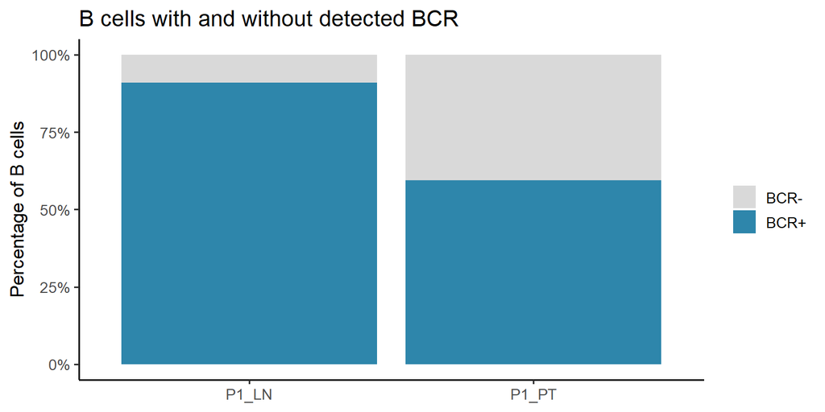

```r
# BCR+ vs BCR- per sample
bcr_counts <- do.call(rbind, lapply(names(samples), function(s_id) {
  obj <- readRDS(file.path(samples[[s_id]]$output_dir,
                           paste0(s_id, "_S4_postBCR.rds")))
  data.frame(Sample = s_id, Status = ifelse(obj$BCR, "BCR+", "BCR-"),
             stringsAsFactors = FALSE)
}))

print(
  ggplot(bcr_counts, aes(x = Sample, fill = Status)) +
    geom_bar(position = "fill") +
    scale_y_continuous(labels = scales::percent_format()) +
    scale_fill_manual(values = c("BCR+" = "#2E86AB", "BCR-" = "#D9D9D9")) +
    labs(title = "B cells with and without detected BCR",
         x = NULL, y = "Percentage of B cells", fill = NULL) +
    theme_classic(base_size = 13)
)
```

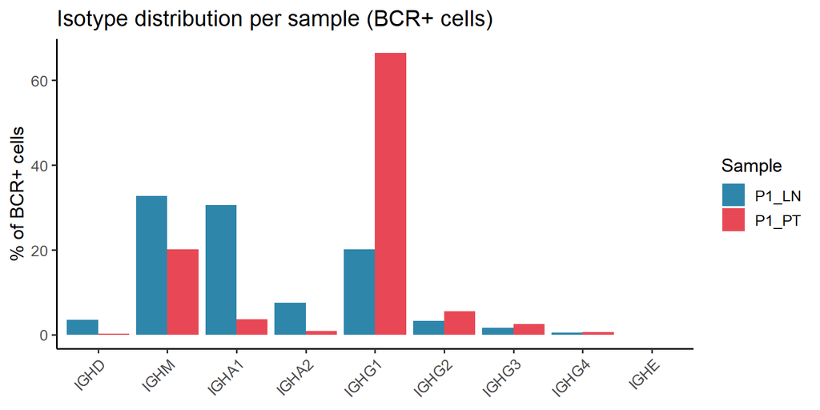

```r
# Isotype distribution per sample
isotype_order <- c("IGHD", "IGHM", "IGHA1", "IGHA2",
                   "IGHG1", "IGHG2", "IGHG3", "IGHG4", "IGHE")

isotype_counts <- do.call(rbind, lapply(names(samples), function(s_id) {
  obj     <- readRDS(file.path(samples[[s_id]]$output_dir,
                               paste0(s_id, "_S4_postBCR.rds")))
  bcr_pos <- subset(obj, subset = BCR == TRUE)
  df <- as.data.frame(table(bcr_pos$c_call), stringsAsFactors = FALSE)
  colnames(df) <- c("Isotype", "Count")
  df$Pct    <- 100 * df$Count / sum(df$Count)
  df$Sample <- s_id
  df
}))

isotype_counts$Isotype <- factor(isotype_counts$Isotype, levels = isotype_order)

print(
  ggplot(isotype_counts, aes(x = Isotype, y = Pct, fill = Sample)) +
    geom_col(position = "dodge") +
    scale_fill_manual(values = c("P1_LN" = "#2E86AB", "P1_PT" = "#E84855")) +
    labs(title = "Isotype distribution per sample (BCR+ cells)",
         x = NULL, y = "% of BCR+ cells", fill = "Sample") +
    theme_classic(base_size = 13) +
    theme(axis.text.x = element_text(angle = 45, hjust = 1))
)
```

The isotype plot makes the LN versus PT contrast immediately visible. P1_LN has a balanced distribution across isotypes while P1_PT is dominated by IgG1 – a single panel that captures the core immunological difference between the two tissue compartments.

# Step 5: Solo GEX Analysis

## 5.1 Why we exclude IG and TCR variable genes from HVG selection

Before running the analysis loop, this non-default choice deserves explanation. The standard Seurat workflow selects the 2,000 most variable genes and uses them for PCA. In B cells this has a specific problem: V(D)J recombination makes the V gene transcripts extremely variable across cells, but this variance reflects clonal diversity – which antibody gene a cell expresses – rather than biological cell state.

If we leave these genes in, PCA and UMAP become partly driven by V gene usage. Cells sharing a V gene get pulled together regardless of transcriptional identity, and biologically meaningful states like germinal center, plasma cell, or memory B cell can get distorted.

The fix: run `FindVariableFeatures()` as normal, then remove any gene matching a V/D/J pattern from the HVG list before scaling and PCA. The genes are **not removed from the object** – they remain available for feature plots, DEG analysis, and everything else. They are only excluded from the features used to compute the embedding.

```r
variable_gene_patterns <- c(
  "^IGHV", "^IGKV", "^IGKJ", "^IGLV", "^IGLJ",
  "^IGHD[0-9]", "^IGHJ",
  "^TRAV", "^TRBV", "^TRAJ", "^TRBJ", "^TRBD"
)
variable_gene_regex <- paste(variable_gene_patterns, collapse = "|")
```

One pattern worth clarifying: `^IGHD[0-9]` catches the IGHD diversity genes (e.g. IGHD3-10), not the IgD isotype transcript. The isotype transcript is named simply `IGHD` with no number suffix and is not matched by this regex. It remains in the HVG list if it is variable, which is correct – IgD expression is one of the best markers distinguishing naive from class-switched B cells.

## 5.2 Marker panel and color scheme

Used for DotPlots and FeaturePlots throughout Steps 5, 6, and 7.

```r
b_cell_markers <- c(
  # B cell identity
  "CD79A", "CD19", "MS4A1",
  # Naive
  "IGHD", "IGHM", "IL4R", "TCL1A",
  # Memory
  "CD27", "CD24", "TNFRSF13B",
  # Germinal center
  "BCL6", "AICDA", "MEF2B",
  # Plasmablast / plasma cell
  "JCHAIN", "MZB1", "XBP1",
  # Proliferating
  "MKI67", "UBE2C", "PCNA",
  # Early activation
  "CD83", "MYC", "CCND2", "TRAF4", "MIR155HG",
  # Interferon-stimulated
  "IFI6", "IFI44", "IFIT1", "IFIT2", "IFIT3",
  # Atypical memory / ABCs
  "FCRL4", "FCRL5", "ZBTB32", "ITGAX", "ZEB2",
  # Exhaustion / regulatory
  "HAVCR1", "HAVCR2", "TIGIT", "LAG3", "IL10"
)

isotype_colors <- c(
  "IGHD"  = "#e41a1c", "IGHM"  = "#377eb8", "IGHA1" = "#a65628",
  "IGHA2" = "#f781bf", "IGHG1" = "#4daf4a", "IGHG2" = "#984ea3",
  "IGHG3" = "#ff7f00", "IGHG4" = "#ffff33", "IGHE"  = "#66c2a5"
)
```

## 5.3 Cell cycle gene sets

```r
s.genes   <- cc.genes.updated.2019$s.genes
g2m.genes <- cc.genes.updated.2019$g2m.genes
```

Cell cycle scores are stored as metadata but not regressed out. In a B cell dataset, cell cycle state is biologically meaningful – proliferating cells are typically dark zone GC B cells undergoing rapid division, and we want this visible in the UMAP.

## 5.4 Per-sample processing loop

For each sample: normalize, find HVGs, exclude IG/TCR variable genes, scale, run PCA, select PCs (fewest explaining 80% of variance, floor 10, ceiling 25), cluster, run UMAP, score cell cycle, generate a full panel of plots, save.

```
## Processing: P1_LN
```

```
##   Loaded: 2292 cells | 18521 genes
```

```
##   Excluding 125 IG/TCR variable genes from HVG list
```

```
##   HVGs after filtering: 1875
```

```
##   PCs selected: 15 (explains 80.3% of variance)
```

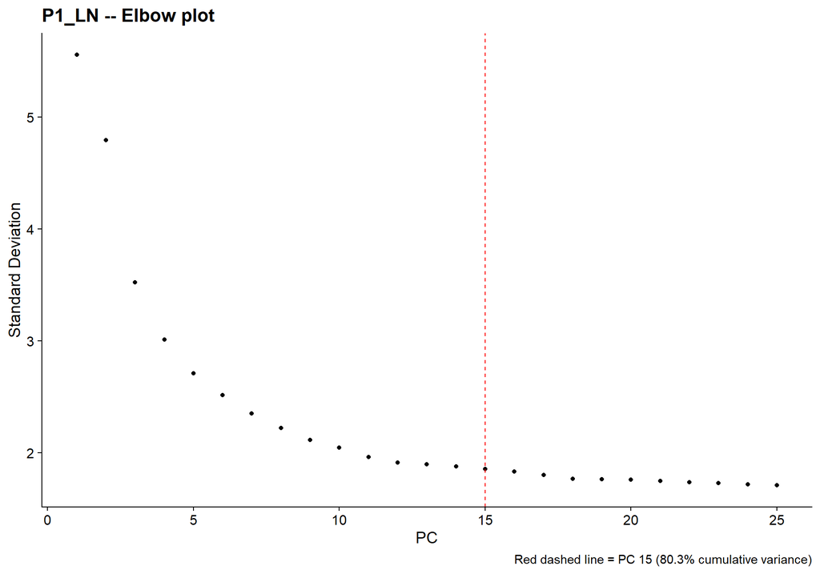

```
##   Clusters found: 6
```

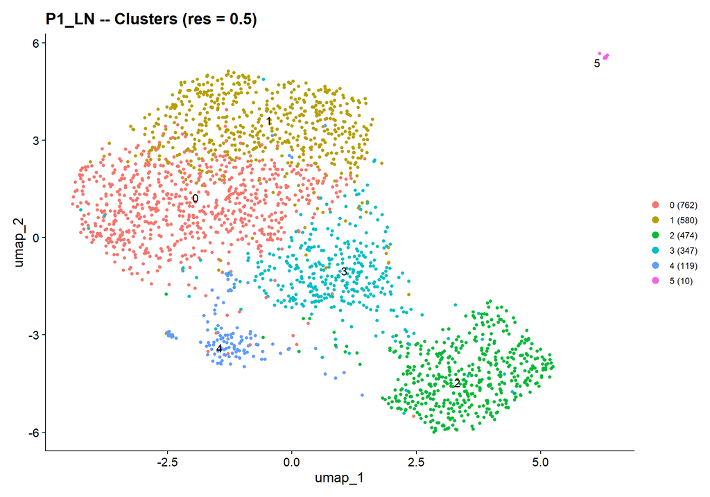

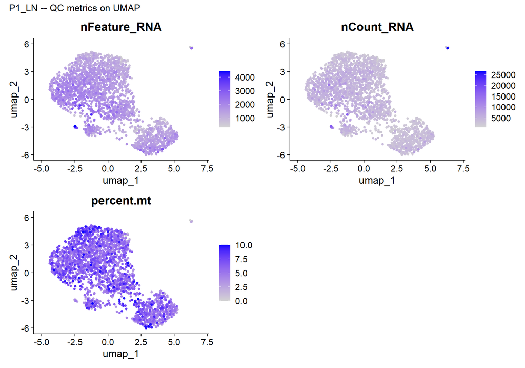

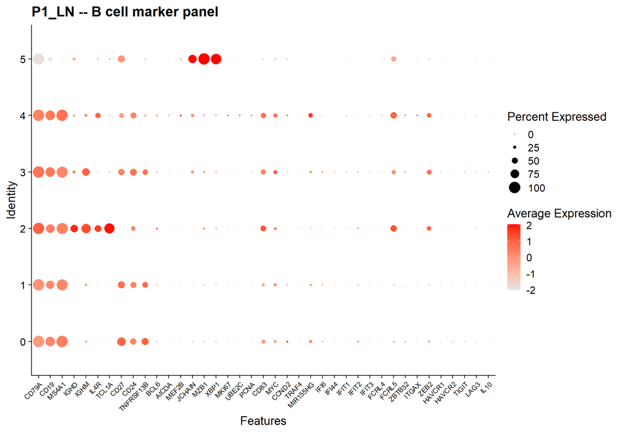

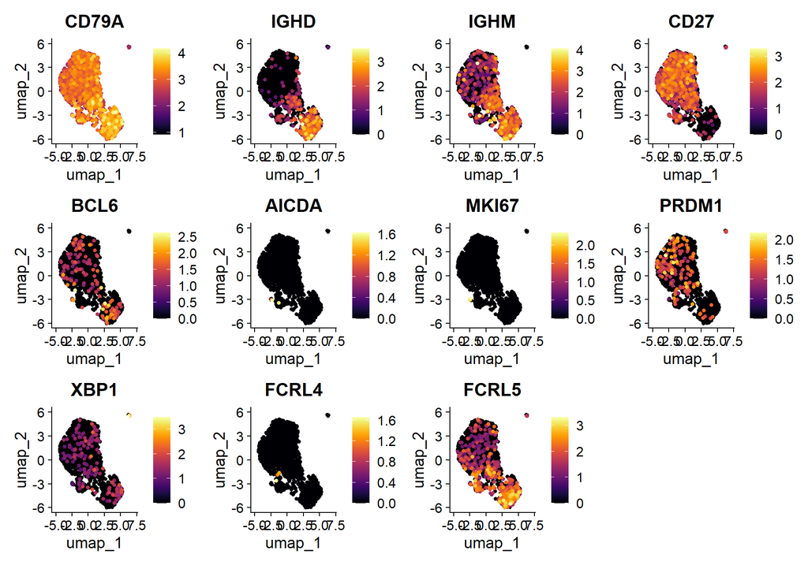

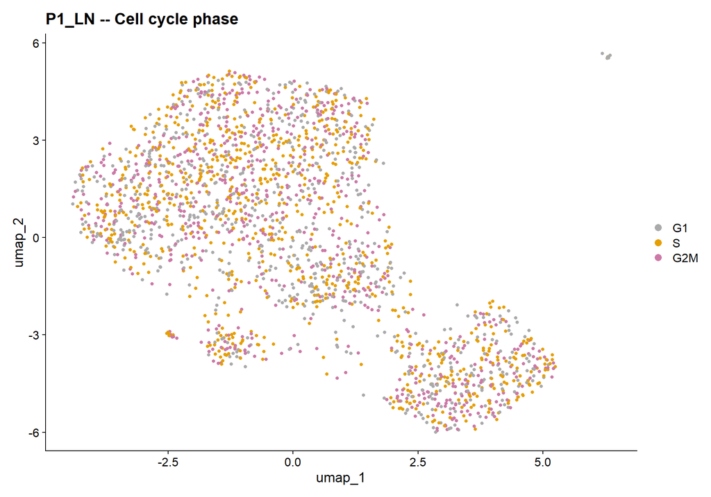

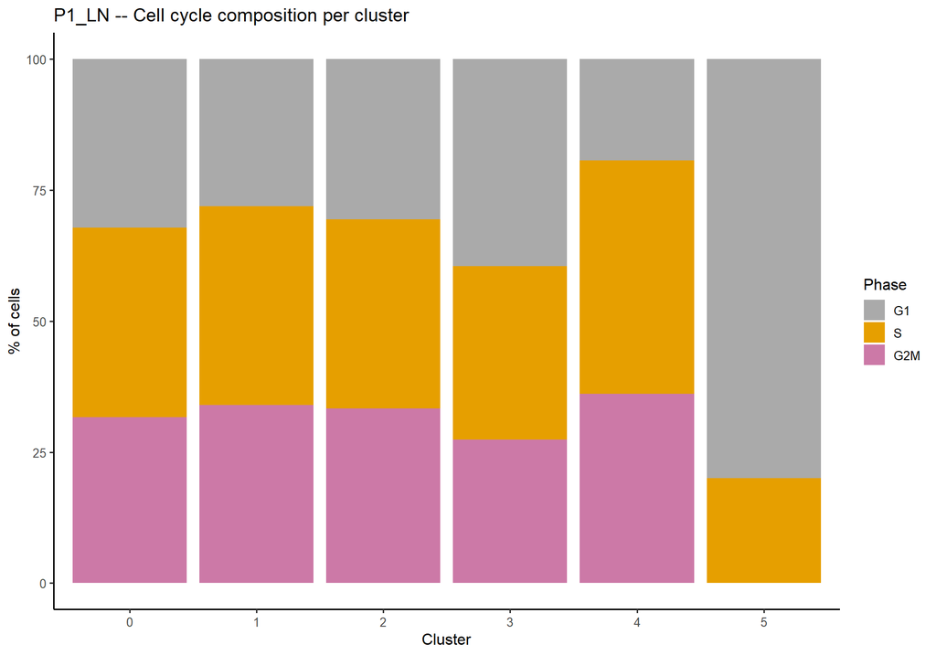

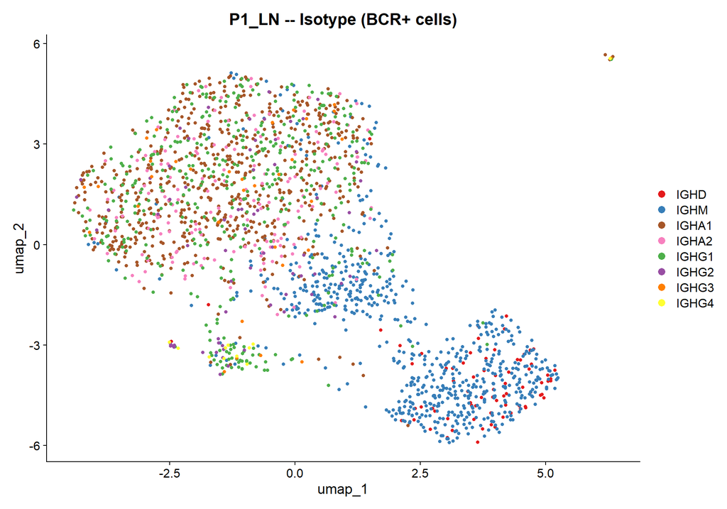

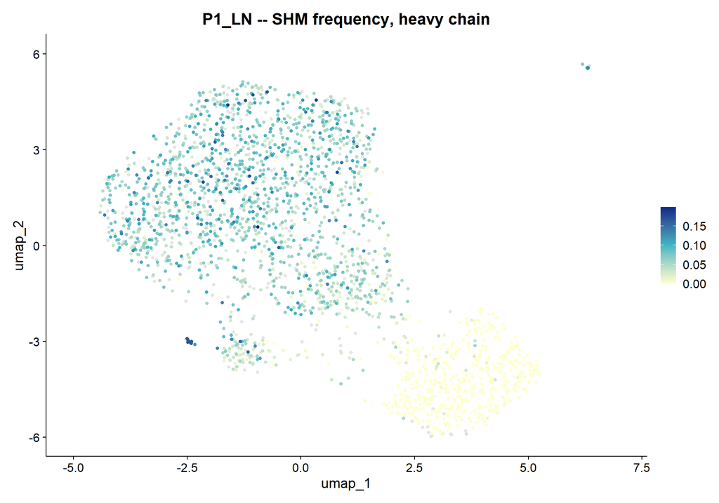

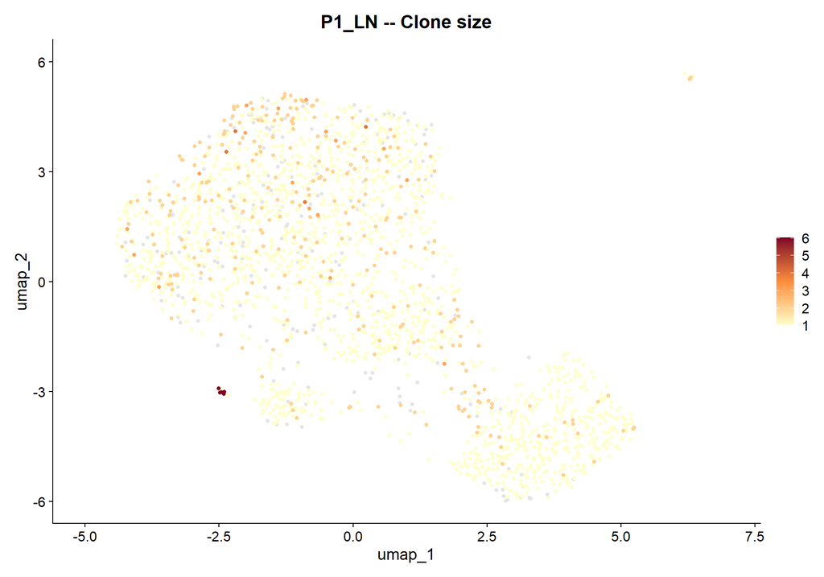

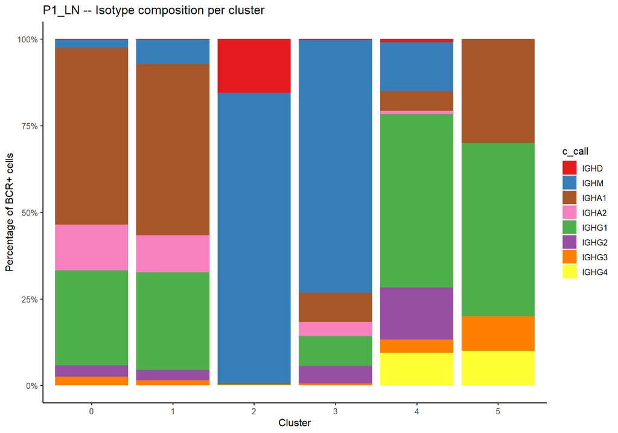

```
##   Saved: C:/Users/natha/OneDrive/Documents/Immcantation/BCR_Tutorial/Github/RDS_Objects/P1_LN_S5_soloProcessed.rds
## ============================================================
## Processing: P1_PT
##   Loaded: 5665 cells | 19889 genes
##   Excluding 185 IG/TCR variable genes from HVG list
##   HVGs after filtering: 1815
##   PCs selected: 10 (explains 83.6% of variance)
```

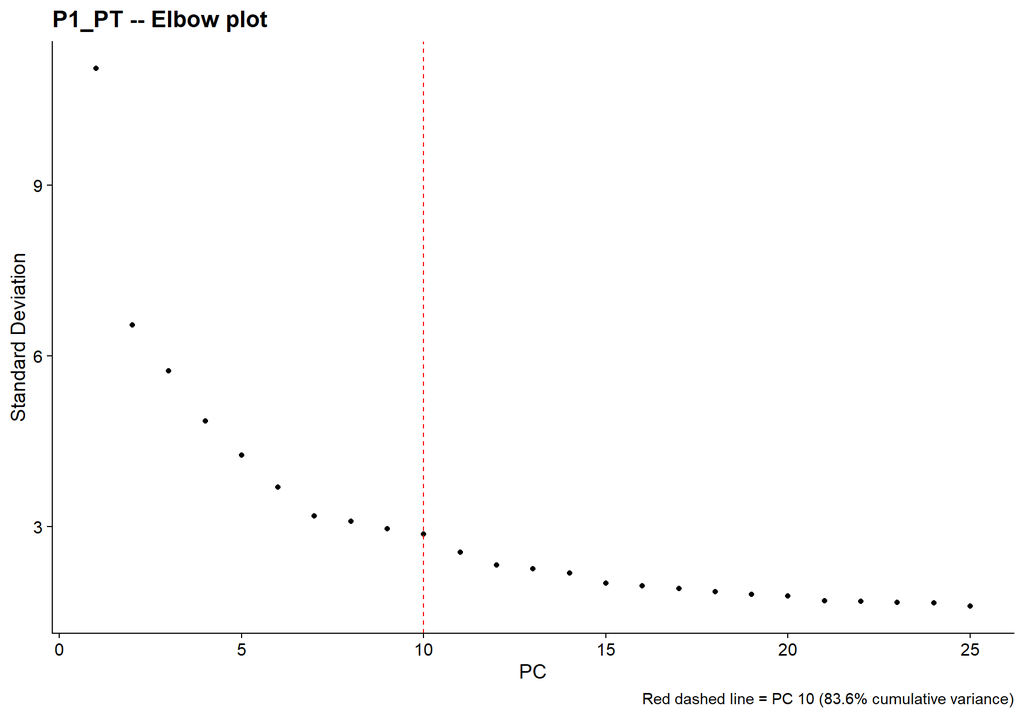

```
##   Clusters found: 11
```

[10 more figures not shown]

```
##   Saved: C:/Users/natha/OneDrive/Documents/Immcantation/BCR_Tutorial/Github/RDS_Objects/P1_PT_S5_soloProcessed.rds
```

```r
set.seed(42)  # ensures reproducibility of RunPCA, FindNeighbors, FindClusters, RunUMAP, and CellCycleScoring across both samples
var_expl           <- 0.8
cluster_resolution <- 0.5
seurat_list        <- list()

for (s in samples) {

  message(paste(rep("=", 60), collapse = ""))
  message("Processing: ", s$sample_id)

  rds_in <- file.path(s$output_dir, paste0(s$sample_id, "_S4_postBCR.rds"))
  if (!file.exists(rds_in)) stop("Cannot find input RDS for ", s$sample_id, " -- run Step 4 first.")
  obj <- readRDS(rds_in)
  DefaultAssay(obj) <- "RNA"
  message("  Loaded: ", ncol(obj), " cells | ", nrow(obj), " genes")

  # Normalize
  obj <- NormalizeData(obj, normalization.method = "LogNormalize",
                       scale.factor = 10000, verbose = FALSE)

  # Find HVGs and exclude IG/TCR variable genes
  obj <- FindVariableFeatures(obj, selection.method = "vst",
                              nfeatures = 2000, verbose = FALSE)
  genes_to_exclude <- grep(variable_gene_regex, rownames(obj), value = TRUE)
  n_excluded       <- length(intersect(genes_to_exclude, VariableFeatures(obj)))
  message("  Excluding ", n_excluded, " IG/TCR variable genes from HVG list")
  hvg_filtered <- setdiff(VariableFeatures(obj), genes_to_exclude)
  if (length(hvg_filtered) < 50) {
    warning("  Fewer than 50 HVGs remain after filtering. Using unfiltered list.")
    hvg_filtered <- VariableFeatures(obj)
  }
  VariableFeatures(obj) <- hvg_filtered
  message("  HVGs after filtering: ", length(hvg_filtered))

  # Scale and PCA
  obj <- ScaleData(obj, features = hvg_filtered, verbose = FALSE)
  obj <- RunPCA(obj, features = hvg_filtered, npcs = 25, verbose = FALSE)

  eigs    <- obj@reductions$pca@stdev^2
  cum_var <- cumsum(eigs) / sum(eigs)
  n_pc    <- which(cum_var >= var_expl)[1]
  if (is.na(n_pc)) n_pc <- 25
  n_pc    <- max(n_pc, 10); n_pc <- min(n_pc, 25)
  message("  PCs selected: ", n_pc,
          " (explains ", round(100 * cum_var[n_pc], 1), "% of variance)")

  print(
    ElbowPlot(obj, ndims = 25) +
      ggtitle(paste0(s$sample_id, " -- Elbow plot")) +
      geom_vline(xintercept = n_pc, linetype = "dashed", color = "red") +
      labs(caption = paste0("Red dashed line = PC ", n_pc,
                            " (", round(100 * cum_var[n_pc], 1), "% cumulative variance)"))
  )

  # Cluster and UMAP
  obj <- FindNeighbors(obj, dims = 1:n_pc, verbose = FALSE)
  obj <- FindClusters(obj, resolution = cluster_resolution, verbose = FALSE)
  obj <- RunUMAP(obj, dims = 1:n_pc, verbose = FALSE)
  message("  Clusters found: ", length(unique(obj$seurat_clusters)))

  # Cell cycle scoring
  obj <- CellCycleScoring(obj, s.features = s.genes,
                          g2m.features = g2m.genes, set.ident = FALSE)
  obj$Phase <- factor(obj$Phase, levels = c("G1", "S", "G2M"))

  # Plots
  num_clusters <- table(obj$seurat_clusters)
  print(
    DimPlot(obj, reduction = "umap", label = TRUE, repel = TRUE, pt.size = 1.2) +
      scale_color_hue(labels = paste0(names(num_clusters), " (", num_clusters, ")")) +
      ggtitle(paste0(s$sample_id, " -- Clusters (res = ", cluster_resolution, ")")) +
      theme(legend.text = element_text(size = 9))
  )

  print(
    FeaturePlot(obj, reduction = "umap",
                features = c("nFeature_RNA", "nCount_RNA", "percent.mt"),
                order = TRUE, pt.size = 1.2) +
      patchwork::plot_annotation(title = paste0(s$sample_id, " -- QC metrics on UMAP"))
  )

  markers_present <- intersect(b_cell_markers, rownames(obj))
  print(
    DotPlot(obj, features = markers_present, cols = c("gray90", "red"), dot.scale = 6) +
      RotatedAxis() +
      ggtitle(paste0(s$sample_id, " -- B cell marker panel")) +
      theme(axis.text.x = element_text(size = 8))
  )

  markers_for_feature <- intersect(
    c("CD79A", "IGHD", "IGHM", "CD27", "BCL6", "AICDA",
      "MKI67", "PRDM1", "XBP1", "FCRL4", "FCRL5"),
    rownames(obj)
  )
  if (length(markers_for_feature) > 0) {
    print(
      FeaturePlot(obj, reduction = "umap", features = markers_for_feature,
                  order = TRUE, pt.size = 1.2) &
        scale_color_gradientn(colors = viridis::inferno(256))
    )
  }

  Idents(obj) <- "Phase"
  print(
    DimPlot(obj, reduction = "umap", label = FALSE, pt.size = 1.2,
            cols = c("G1" = "#AAAAAA", "S" = "#E69F00", "G2M" = "#CC79A7")) +
      ggtitle(paste0(s$sample_id, " -- Cell cycle phase"))
  )
  Idents(obj) <- "seurat_clusters"

  cc_df <- obj@meta.data %>%
    dplyr::select(Phase, seurat_clusters) %>%
    dplyr::group_by(seurat_clusters, Phase) %>%
    dplyr::summarise(n = dplyr::n(), .groups = "drop_last") %>%
    dplyr::mutate(pct = 100 * n / sum(n)) %>%
    dplyr::ungroup() %>%
    dplyr::mutate(Phase = factor(Phase, levels = c("G1", "S", "G2M")))

  print(
    ggplot(cc_df, aes(x = seurat_clusters, y = pct, fill = Phase)) +
      geom_bar(stat = "identity") +
      scale_fill_manual(values = c("G1" = "#AAAAAA", "S" = "#E69F00", "G2M" = "#CC79A7")) +
      ylab("% of cells") + xlab("Cluster") +
      theme_classic(base_size = 12) +
      ggtitle(paste0(s$sample_id, " -- Cell cycle composition per cluster"))
  )

  # BCR overlay plots
  if ("BCR" %in% colnames(obj@meta.data)) {

    obj_bcr <- subset(obj, subset = !is.na(c_call) & c_call != "")
    if (ncol(obj_bcr) > 0) {
      obj_bcr$c_call <- factor(obj_bcr$c_call, levels = isotype_order)
      present_iso    <- intersect(isotype_order, levels(droplevels(obj_bcr$c_call)))
      print(
        DimPlot(obj_bcr, group.by = "c_call", label = FALSE, pt.size = 1.2,
                cols = isotype_colors[present_iso], order = rev(present_iso)) +
          ggtitle(paste0(s$sample_id, " -- Isotype (BCR+ cells)"))
      )
    }

    if ("mu_freq_H" %in% colnames(obj@meta.data)) {
      print(
        FeaturePlot(obj, features = "mu_freq_H", reduction = "umap",
                    order = TRUE, pt.size = 1.2) +
          scale_color_gradientn(colors = c("#FFFFCC", "#41B6C4", "#0C2C84"),
                                na.value = "grey90") +
          ggtitle(paste0(s$sample_id, " -- SHM frequency, heavy chain"))
      )
    }

    if ("clone_count" %in% colnames(obj@meta.data)) {
      print(
        FeaturePlot(obj, features = "clone_count", reduction = "umap",
                    order = TRUE, pt.size = 1.2) +
          scale_color_gradientn(colors = c("#FFFFCC", "#FD8D3C", "#800026"),
                                na.value = "grey90") +
          ggtitle(paste0(s$sample_id, " -- Clone size"))
      )
    }

    if ("c_call" %in% colnames(obj@meta.data)) {
      iso_df <- obj@meta.data %>%
        dplyr::filter(!is.na(c_call), c_call != "", !is.na(seurat_clusters)) %>%
        dplyr::mutate(c_call          = factor(c_call, levels = isotype_order),
                      seurat_clusters = as.factor(seurat_clusters))
      present_iso2 <- intersect(isotype_order, levels(droplevels(iso_df$c_call)))
      print(
        ggplot(iso_df, aes(x = seurat_clusters, y = 1, fill = c_call)) +
          geom_col(position = "fill") +
          scale_y_continuous(labels = scales::label_percent(accuracy = 1)) +
          scale_fill_manual(values = isotype_colors[present_iso2], breaks = present_iso2) +
          ylab("Percentage of BCR+ cells") + xlab("Cluster") +
          theme_classic(base_size = 12) +
          ggtitle(paste0(s$sample_id, " -- Isotype composition per cluster"))
      )
    }
  }

  Idents(obj) <- "seurat_clusters"
  rds_out <- file.path(s$output_dir, paste0(s$sample_id, "_S5_soloProcessed.rds"))
  saveRDS(obj, file = rds_out)
  message("  Saved: ", rds_out)

  seurat_list[[s$sample_id]] <- obj
}
```

## 5.5 Interpreting the P1_LN results

**There is no germinal center cluster in P1_LN.** The lymph node is where germinal center reactions are supposed to occur, yet there is no BCL6/AICDA- enriched cluster here. This is a key finding of the paper: these tumor-draining lymph nodes are functionally compromised, with B cells that are resting rather than actively responding.

## 5.6 Interpreting the P1_PT results

P1_PT yields 5,665 B cells across 11 clusters – considerably more cells and transcriptional diversity than the LN. Cluster 1 (21.2%) is marked by FCRL4, FCRL5, and ITGAX – atypical memory B cells (ABCs), which accumulate in settings of chronic antigen exposure including tumors. Clusters 2, 6, and 10 form the plasma cell compartment (JCHAIN, MZB1, XBP1). Clusters 4 and 8 are GC B cells (BCL6, AICDA, MEF2B). Cluster 5 (8.1%) is a clean proliferating cluster (MKI67, UBE2C, PCNA). Cluster 3 (11.2%) is interferon-stimulated (IFIT1/2/3, OASL) – entirely absent from the LN.

The LN contains a polyclonal, resting memory B cell pool with no active GC response and no clonal expansion. The PT contains an oligoclonal, transcriptionally diverse infiltrate with active GC reactions, expanded plasma cell and atypical memory populations, a proliferating cluster, and large antigen-driven clones. This contrast is one of the central findings of the paper and is fully visible at this pre-integration stage.

# Step 6: Integration

## 6.1 Why integration is necessary

Without integration, technical variation between samples – sequencing depth, capture efficiency, ambient RNA – can drive UMAP separation that has nothing to do with biology. A naive merge of the two objects would almost certainly produce sample-specific clusters, making it impossible to distinguish a real biological difference (LN vs PT) from a technical artifact.

We use RPCA (Reciprocal PCA) integration via Seurat v5’s `IntegrateLayers()`. RPCA projects each dataset into the PCA space of the other, identifies mutual nearest neighbors as integration anchors, and corrects each sample’s embedding toward a shared space. It is conservative: it corrects technical offsets while preserving real biological differences. It works best when samples share a meaningful proportion of cell types – which is exactly the case here, since both samples contain memory and naive B cells.

## 6.2 Choosing an integration method

Three methods are available in Seurat v5:

**RPCA** (used here): conservative, fast, best for same-platform same-experiment data with shared cell types.

**CCA**: more aggressive, can overcorrect similar samples but handles very different conditions better. To switch: change `method = RPCAIntegration` to `method = CCAIntegration` and update `new.reduction` accordingly.

**Harmony**: operates on PCA embeddings directly, scales well to many samples (>10) and large datasets (>50k cells). To use: change `method = RPCAIntegration` to `method = HarmonyIntegration` and install the `harmony` package.

Integration does not modify the count matrix. The `RNA` assay is always unchanged. All downstream analysis – differential expression, feature plots – should use the `RNA` assay.

## 6.3 Load, merge, and prepare layers

```r
seurat_list_s5 <- list()
for (s in samples) {
  rds_in <- file.path(s$output_dir, paste0(s$sample_id, "_S5_soloProcessed.rds"))
  if (!file.exists(rds_in)) stop("Cannot find RDS for ", s$sample_id, " -- run Step 5 first.")
  obj <- readRDS(rds_in)
  obj$sample_id <- s$sample_id
  seurat_list_s5[[s$sample_id]] <- obj
  message("Loaded: ", s$sample_id, " -- ", ncol(obj), " cells | ", nrow(obj), " genes")
}
```

```
## Loaded: P1_LN -- 2292 cells | 18521 genes
```

```
## Loaded: P1_PT -- 5665 cells | 19889 genes
```

```r
merged <- merge(x = seurat_list_s5[[1]], y = seurat_list_s5[-1])
message("Merged object: ", ncol(merged), " cells | ", nrow(merged), " genes")
```

```
## Merged object: 7957 cells | 20990 genes
```

```r
DefaultAssay(merged) <- "RNA"
merged[["RNA"]] <- JoinLayers(merged[["RNA"]])
merged[["RNA"]] <- split(merged[["RNA"]], f = merged$sample_id)
```

```
## Splitting 'counts', 'data' layers. Not splitting 'scale.data'. If you would like to split other layers, set in `layers` argument.
```

```r
message("Layers after split: ", paste(Layers(merged), collapse = ", "))
```

```
## Layers after split: counts.P1_LN, counts.P1_PT, scale.data, data.P1_LN, data.P1_PT
```

## 6.4 Normalize, find HVGs, scale, PCA (unintegrated)

We re-normalize on the merged object because `merge()` in Seurat v5 combines raw count layers but does not carry over the normalized data layer. The same IG/TCR variable gene exclusion from Step 5 is applied here.

```r
set.seed(42)  # ensures reproducibility of RunPCA on the merged object
merged <- NormalizeData(merged, normalization.method = "LogNormalize",
                        scale.factor = 10000, verbose = FALSE)
merged <- FindVariableFeatures(merged, selection.method = "vst",
                               nfeatures = 2000, verbose = FALSE)

genes_to_exclude_m <- grep(variable_gene_regex, rownames(merged), value = TRUE)
n_excluded_m       <- length(intersect(genes_to_exclude_m, VariableFeatures(merged)))
hvg_filtered_m     <- setdiff(VariableFeatures(merged), genes_to_exclude_m)
message("IG/TCR variable genes excluded: ", n_excluded_m)
```

```
## IG/TCR variable genes excluded: 172
```

```r
message("HVGs after filtering: ", length(hvg_filtered_m))
```

```
## HVGs after filtering: 1828
```

```r
VariableFeatures(merged) <- hvg_filtered_m

merged <- ScaleData(merged, features = hvg_filtered_m, verbose = FALSE)
merged <- RunPCA(merged, features = hvg_filtered_m, npcs = 25, verbose = FALSE)

eigs_m    <- merged@reductions$pca@stdev^2
cum_var_m <- cumsum(eigs_m) / sum(eigs_m)
n_pc_m    <- which(cum_var_m >= 0.8)[1]
if (is.na(n_pc_m)) n_pc_m <- 25
n_pc_m    <- max(n_pc_m, 10); n_pc_m <- min(n_pc_m, 25)
message("PCs selected: ", n_pc_m,
        " (explains ", round(100 * cum_var_m[n_pc_m], 1), "% of variance)")
```

```
## PCs selected: 10 (explains 82.8% of variance)
```

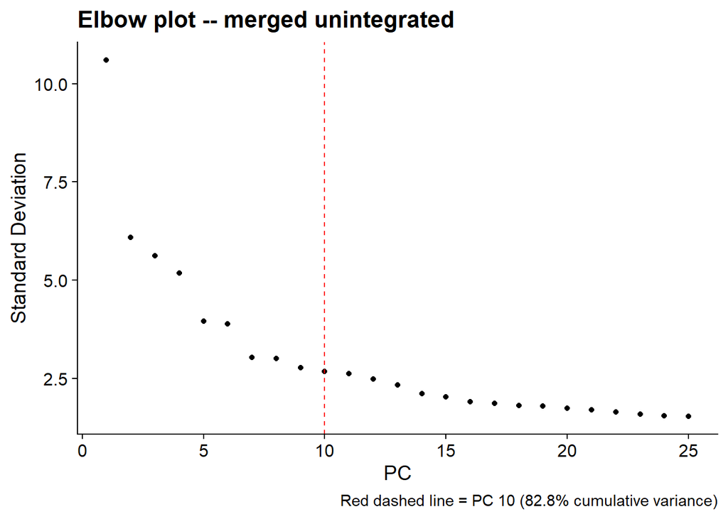

```r
print(
  ElbowPlot(merged, ndims = 25) +
    ggtitle("Elbow plot -- merged unintegrated") +
    geom_vline(xintercept = n_pc_m, linetype = "dashed", color = "red") +
    labs(caption = paste0("Red dashed line = PC ", n_pc_m,
                          " (", round(100 * cum_var_m[n_pc_m], 1), "% cumulative variance)"))
)
```

## 6.5 Pre-integration UMAP

This UMAP is run on the unintegrated PCA solely to show the batch effect before correction. It is stored as `umap.unintegrated` and is not used in any downstream analysis.

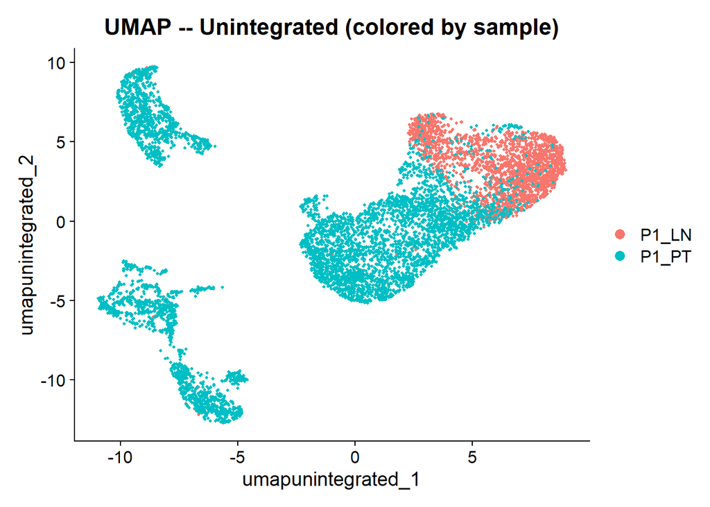

```r
set.seed(42)  # ensures reproducibility of the pre-integration RunUMAP
merged <- RunUMAP(merged, dims = 1:n_pc_m, reduction = "pca",
                  reduction.name = "umap.unintegrated", verbose = FALSE)

print(
  DimPlot(merged, reduction = "umap.unintegrated", group.by = "sample_id",
          pt.size = 0.8) +
    ggtitle("UMAP -- Unintegrated (colored by sample)") +
    theme(plot.title = element_text(hjust = 0.5))
)
```

If the two samples form largely separate clouds, that confirms a batch component to correct. If they already overlap almost completely, integration will have little effect but is still worth running.

## 6.6 RPCA integration

```r
set.seed(42)  # ensures reproducibility of IntegrateLayers (RPCA anchor finding is stochastic)
options(future.globals.maxSize = 2000 * 1024^2)

merged <- IntegrateLayers(
  object         = merged,
  method         = RPCAIntegration,
  orig.reduction = "pca",
  new.reduction  = "integrated.rpca",
  verbose        = FALSE
)

merged[["RNA"]] <- JoinLayers(merged[["RNA"]])
message("Integration complete. Layers rejoined.")
```

```
## Integration complete. Layers rejoined.
```

## 6.7 Cluster and UMAP on integrated embedding

Resolution 0.5 produces 10 clusters that map cleanly onto recognizable B cell states for this dataset. If your clusters look heterogeneous on the DotPlot, try 0.7 or 1.0. If many clusters look identical, try 0.3 or 0.4.

```r
set.seed(42)  # ensures reproducibility of FindNeighbors, FindClusters, and RunUMAP on the integrated embedding
merged <- FindNeighbors(merged, dims = 1:n_pc_m,
                        reduction = "integrated.rpca", verbose = FALSE)
merged <- FindClusters(merged, resolution = 0.5, verbose = FALSE)
merged <- RunUMAP(merged, dims = 1:n_pc_m,
                  reduction = "integrated.rpca", verbose = FALSE)
message("Clusters found: ", length(unique(merged$seurat_clusters)))
```

```
## Clusters found: 10
```

## 6.8 Evaluating integration

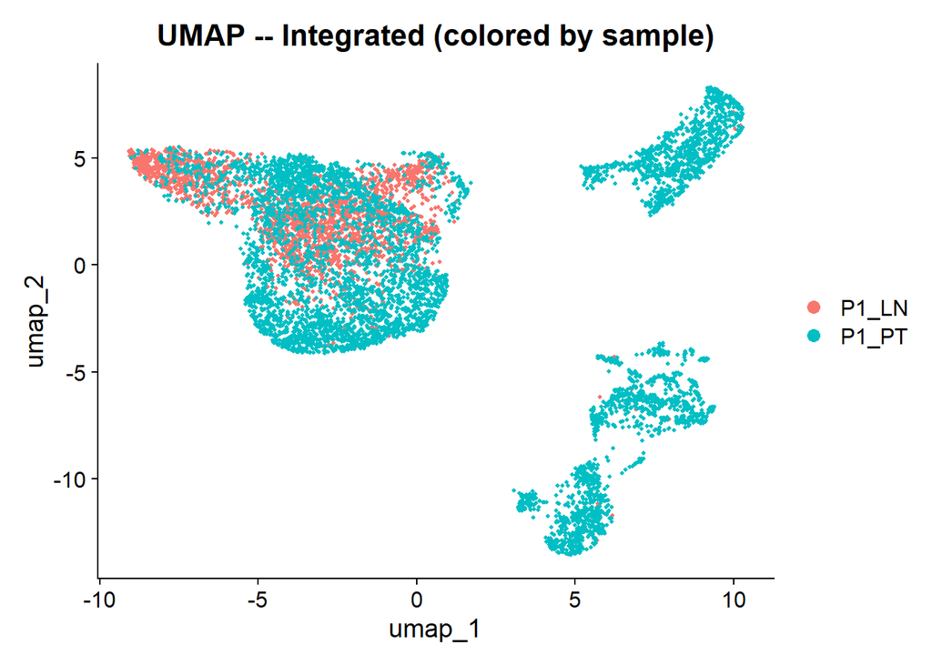

```r
print(
  DimPlot(merged, reduction = "umap", group.by = "sample_id", pt.size = 0.8) +
    ggtitle("UMAP -- Integrated (colored by sample)") +
    theme(plot.title = element_text(hjust = 0.5))
)
```

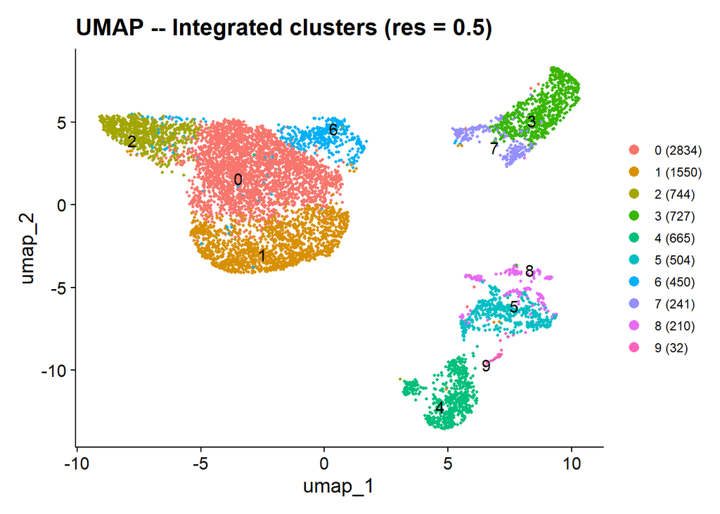

```r
num_clusters_m <- table(merged$seurat_clusters)
print(
  DimPlot(merged, reduction = "umap", label = TRUE, repel = TRUE, pt.size = 0.8) +
    scale_color_hue(labels = paste0(names(num_clusters_m), " (", num_clusters_m, ")")) +
    ggtitle("UMAP -- Integrated clusters (res = 0.5)") +
    theme(legend.text = element_text(size = 9))
)
```

After successful RPCA integration, cells from P1_LN and P1_PT should intermingle within shared clusters rather than forming two separate islands. Genuine biological differences between LN and PT will remain visible as differences in cluster proportions, not wholesale spatial separation.

## 6.9 Cluster composition by sample

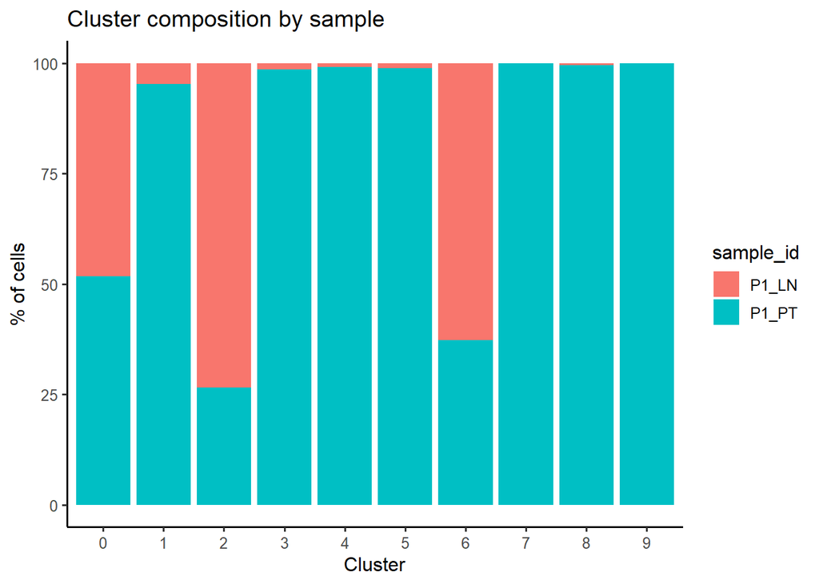

```r
comp_df <- merged@meta.data %>%
  dplyr::select(seurat_clusters, sample_id) %>%
  dplyr::group_by(seurat_clusters, sample_id) %>%
  dplyr::summarise(n = dplyr::n(), .groups = "drop_last") %>%
  dplyr::mutate(pct = 100 * n / sum(n)) %>%
  dplyr::ungroup()

print(
  ggplot(comp_df, aes(x = seurat_clusters, y = pct, fill = sample_id)) +
    geom_bar(stat = "identity") +
    ylab("% of cells") + xlab("Cluster") +
    theme_classic(base_size = 12) +
    ggtitle("Cluster composition by sample")
)
```

## 6.10 Save integrated object

```r
rds_out_s6 <- file.path(RDS_DIR, "integrated_S6.rds")
saveRDS(merged, file = rds_out_s6)
message("Saved: ", rds_out_s6)
```

```
## Saved: C:/Users/natha/OneDrive/Documents/Immcantation/BCR_Tutorial/Github/RDS_Objects/integrated_S6.rds
```

```r
message("Cells: ", ncol(merged), " | Clusters: ", length(unique(merged$seurat_clusters)))
```

```
## Cells: 7957 | Clusters: 10
```

# Step 7: Cluster Annotation

## 7.1 Load the integrated object

```r
rds_in_s7 <- file.path(RDS_DIR, "integrated_S6.rds")
if (!file.exists(rds_in_s7)) stop("Cannot find integrated RDS -- run Step 6 first.")

obj <- readRDS(rds_in_s7)
DefaultAssay(obj) <- "RNA"
Idents(obj) <- "seurat_clusters"

num_clusters_s7 <- table(obj$seurat_clusters)
message("Loaded: ", ncol(obj), " cells | ", length(num_clusters_s7), " clusters")
```

```
## Loaded: 7957 cells | 10 clusters
```

## 7.2 Cell cycle scoring

Cell cycle phase was computed in Step 5 on the per-sample objects. We check whether it carried through the merge; if not, we score it here.

```r
set.seed(42)  # ensures reproducibility of CellCycleScoring if it runs here
if (!"Phase" %in% colnames(obj@meta.data)) {
  message("Phase column not found -- scoring cell cycle on integrated object...")
  obj <- CellCycleScoring(obj, s.features = s.genes,
                          g2m.features = g2m.genes, set.ident = FALSE)
  message("Cell cycle scoring complete.")
} else {
  message("Phase column already present -- skipping scoring.")
}
```

```
## Phase column already present -- skipping scoring.
```

```r
obj$Phase <- factor(obj$Phase, levels = c("G1", "S", "G2M"))
Idents(obj) <- "seurat_clusters"
```

## 7.3 UMAP by cluster and by sample

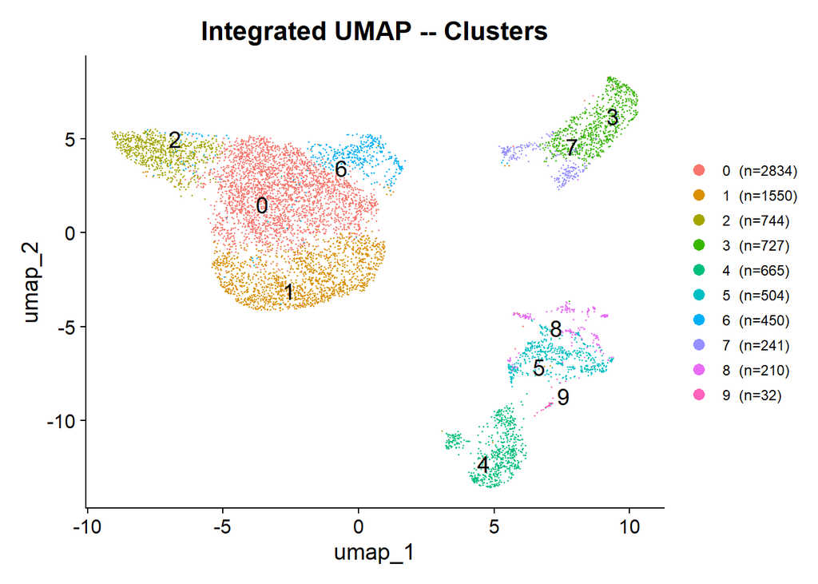

```r
print(
  DimPlot(obj, reduction = "umap", label = TRUE, label.size = 5, repel = TRUE) +
    scale_color_hue(labels = paste0(names(num_clusters_s7), "  (n=", num_clusters_s7, ")")) +
    ggtitle("Integrated UMAP -- Clusters") +
    theme(plot.title  = element_text(hjust = 0.5),
          legend.text = element_text(size = 9))
)
```

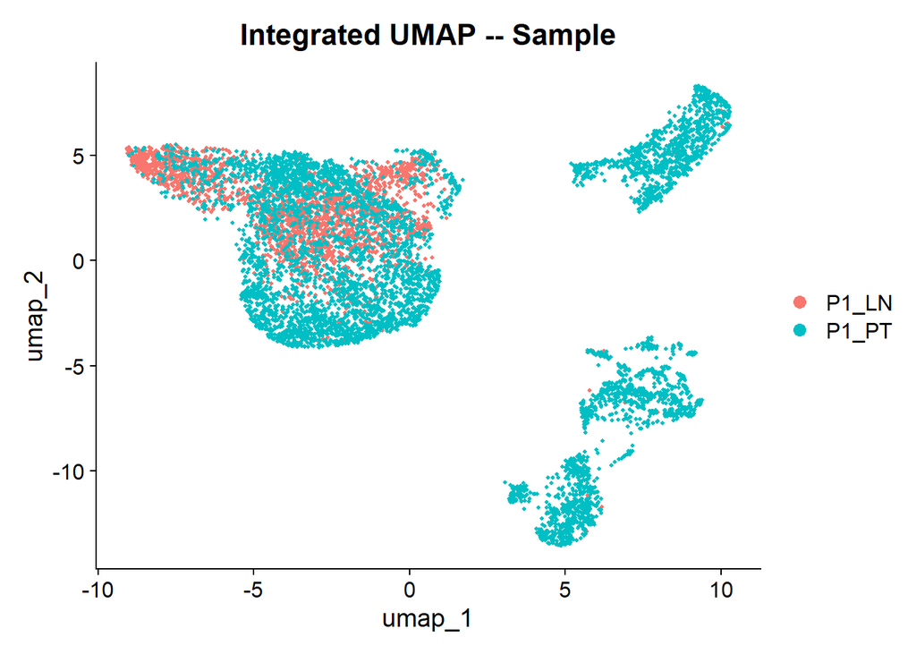

```r
print(
  DimPlot(obj, reduction = "umap", group.by = "sample_id",
          label = FALSE, pt.size = 0.8) +
    ggtitle("Integrated UMAP -- Sample") +
    theme(plot.title = element_text(hjust = 0.5))
)
```

## 7.4 B cell marker DotPlot

The DotPlot is the primary annotation tool. Read it row by row and look for the marker group that lights up. Pay attention to both dot size (percent expressing) and color (average expression level). This is the first pass. Several clusters will be immediately classifiable, while others will need additional evidence from BCR metadata and DEG analysis.

Clusters 0, 1, and 6 express memory B cell markers (CD27, CD24, TNFRSF13B). Clusters 0 and 6 share this profile with no other distinguishing markers between them and will need DEG analysis to separate. Cluster 1 stands out with FCRL4, FCRL5, and a clear interferon signature (IFIT1, IFIT3, IFI44, MX1), consistent with atypical memory B cells. IFN and stress signaling are known drivers of the atypical MBC program in the literature, which is why these features co-occur in the same population.

Cluster 2 is unambiguous naive: TCL1A, IGHD, IGHM, and IL4R.

Clusters 4 and 5 both express the GC program (BCL6, AICDA, MEF2B). Cluster 5 adds a cycling signature (MKI67, UBE2C, PCNA), so cluster 4 is non-cycling GC and cluster 5 is cycling GC.

Clusters 3, 7, and 8 express plasma cell markers (JCHAIN, MZB1, XBP1). Clusters 3 and 7 are typical PC with no other distinguishing features. Cluster 8 adds cycling markers on top of the PC program, suggesting a plasmablast-like or cycling PC population.

Cluster 9 is a small cluster (32 cells) with no obvious signature. At this size it may not represent a distinct population, and could be the leading edge of a cluster that would resolve with more cells.

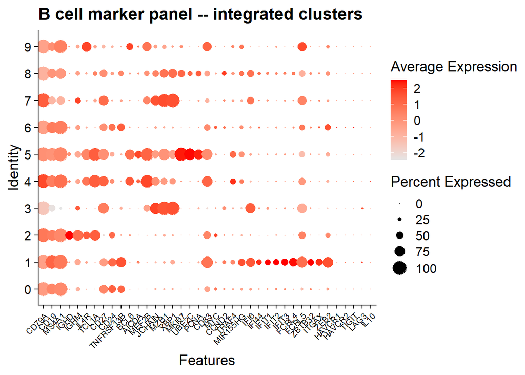

```r
markers_present_s7 <- intersect(b_cell_markers, rownames(obj))
print(
  DotPlot(obj, features = markers_present_s7,
          cols = c("gray90", "red"), dot.scale = 6) +
    RotatedAxis() +
    ggtitle("B cell marker panel -- integrated clusters") +
    theme(axis.text.x = element_text(size = 8))
)
```

## 7.5 Sample composition per cluster

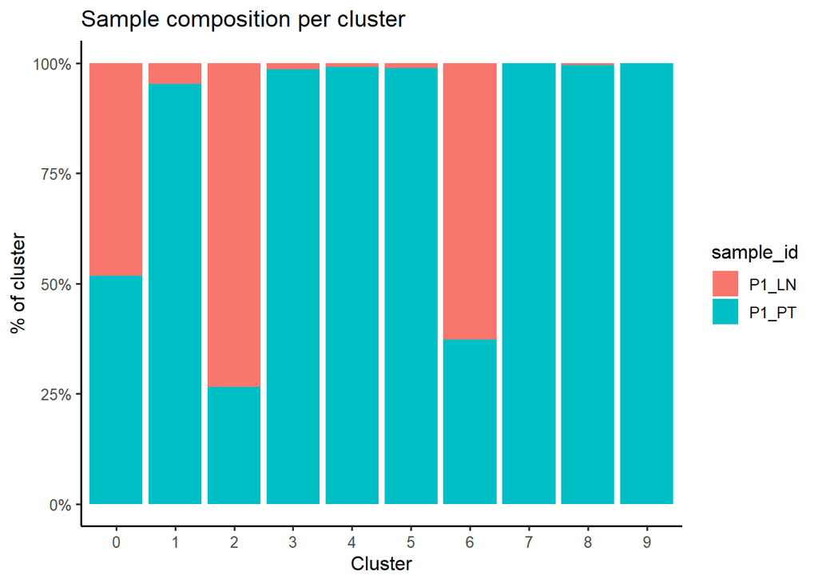

```r
sample_df_s7 <- obj@meta.data %>%
  dplyr::select(sample_id, seurat_clusters) %>%
  dplyr::group_by(seurat_clusters, sample_id) %>%
  dplyr::summarise(n = dplyr::n(), .groups = "drop_last") %>%
  dplyr::mutate(pct = 100 * n / sum(n)) %>%
  dplyr::ungroup()

print(
  ggplot(sample_df_s7, aes(x = seurat_clusters, y = pct, fill = sample_id)) +
    geom_bar(stat = "identity") +
    scale_y_continuous(labels = scales::label_percent(scale = 1, accuracy = 1)) +
    ylab("% of cluster") + xlab("Cluster") +
    theme_classic(base_size = 12) +
    ggtitle("Sample composition per cluster")
)
```

Clusters 0 and 6 are substantially mixed between LN and PT, consistent with quiescent memory B cell populations found in both tissues. Cluster 2 is predominantly LN-derived (~75%), as expected for naive B cells. All remaining clusters are predominantly or exclusively PT-derived.

## 7.6 FeaturePlots: key marker genes on UMAP

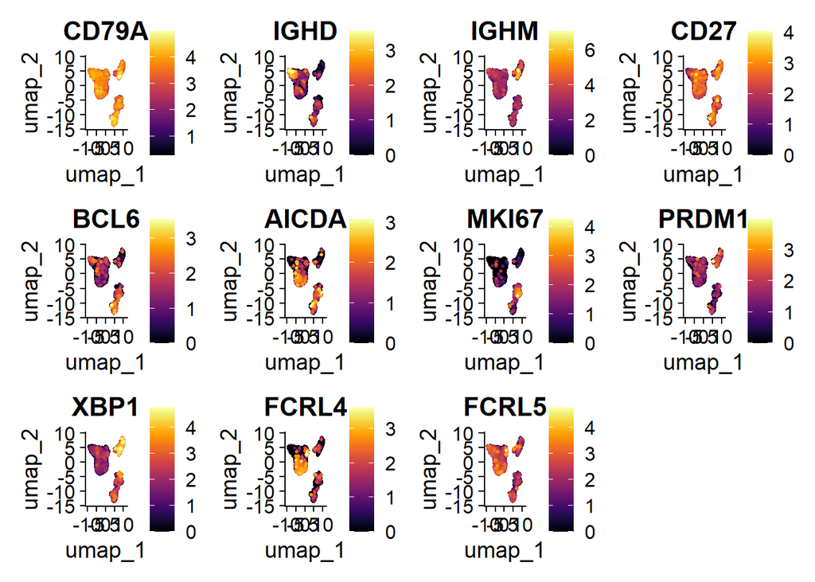

```r
markers_for_feature_s7 <- intersect(
  c("CD79A", "IGHD", "IGHM", "CD27", "BCL6", "AICDA",
    "MKI67", "PRDM1", "XBP1", "FCRL4", "FCRL5"),
  rownames(obj)
)
if (length(markers_for_feature_s7) > 0) {
  print(
    FeaturePlot(obj, reduction = "umap", features = markers_for_feature_s7,
                order = TRUE, pt.size = 0.8) &
      scale_color_gradientn(colors = viridis::inferno(256))
  )
}
```

## 7.7 Isotype composition per cluster

Isotype composition adds a BCR-level layer of evidence that transcriptomics alone cannot provide. Two clusters that both express CD27 can be distinguished if one is IgM-dominant (unswitched) and the other is IgG-dominant (class-switched).

Cluster 2 is predominantly IgM/IgD, consistent with its naive identity. Clusters 0 and 6 show mixed isotype composition. The remaining clusters are predominantly IgG1-dominant and are also largely PT-derived, highlighting a tissue-level difference: the LN is enriched for IgM and mixed isotype populations, while the PT is dominated by class-switched IgG.

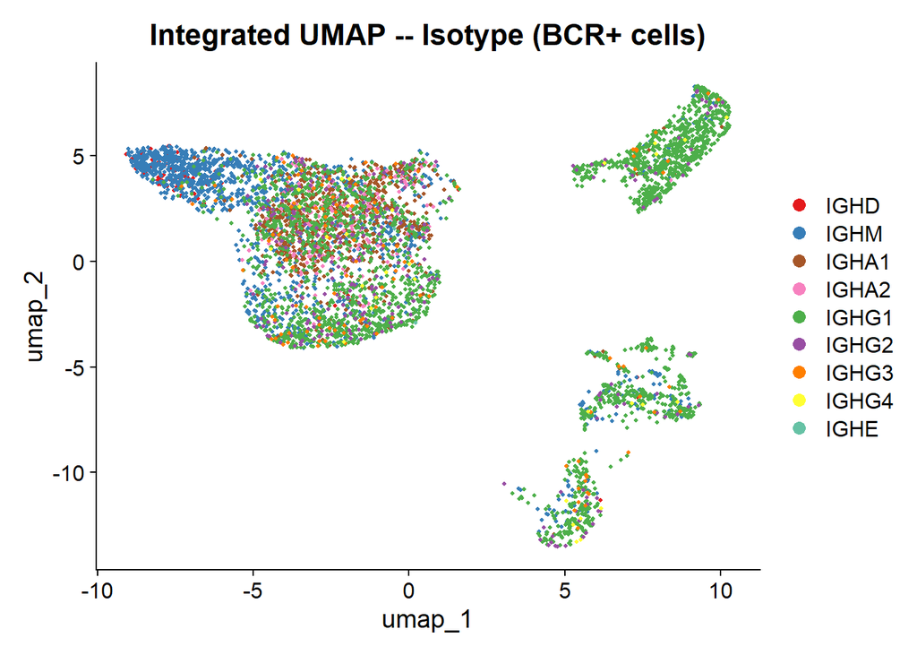

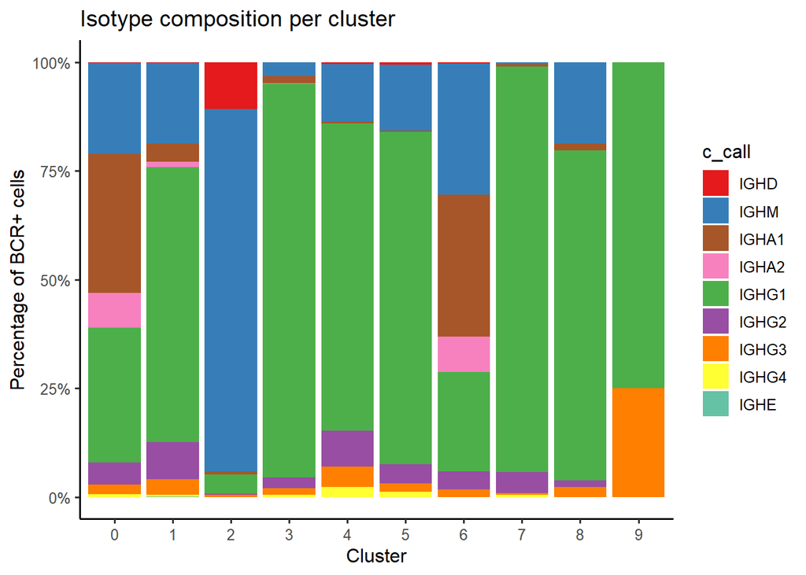

```r
if ("c_call" %in% colnames(obj@meta.data)) {

  obj_bcr_s7 <- subset(obj, subset = !is.na(c_call) & c_call != "")
  if (ncol(obj_bcr_s7) > 0) {
    obj_bcr_s7$c_call <- factor(obj_bcr_s7$c_call, levels = isotype_order)
    present_iso_s7    <- intersect(isotype_order, levels(droplevels(obj_bcr_s7$c_call)))
    print(
      DimPlot(obj_bcr_s7, group.by = "c_call", label = FALSE, pt.size = 0.8,
              cols = isotype_colors[present_iso_s7], order = rev(present_iso_s7),
              reduction = "umap") +
        ggtitle("Integrated UMAP -- Isotype (BCR+ cells)")
    )
  }

  iso_df_s7 <- obj@meta.data %>%
    dplyr::filter(!is.na(c_call), c_call != "", !is.na(seurat_clusters)) %>%
    dplyr::mutate(c_call          = factor(c_call, levels = isotype_order),
                  seurat_clusters = as.factor(seurat_clusters))
  present_iso_s7b <- intersect(isotype_order, levels(droplevels(iso_df_s7$c_call)))
  print(
    ggplot(iso_df_s7, aes(x = seurat_clusters, y = 1, fill = c_call)) +
      geom_col(position = "fill") +
      scale_y_continuous(labels = scales::label_percent(accuracy = 1)) +
      scale_fill_manual(values = isotype_colors[present_iso_s7b],
                        breaks = present_iso_s7b) +
      ylab("Percentage of BCR+ cells") + xlab("Cluster") +
      theme_classic(base_size = 12) +
      ggtitle("Isotype composition per cluster")
  )
}
```

## 7.8 SHM frequency and clonality per cluster

SHM frequency adds a further layer of evidence. Cluster 2 is clearly the lowest in the dataset with a near-zero median, consistent with its naive identity. Cluster 1 is notably lower than the other memory clusters (median ~0.03 vs ~0.06 for clusters 0 and 6). The remaining clusters (0, 3, 4, 5, 6, 7, 8) are broadly similar in the ~0.05-0.06 range. Cluster 9 appears elevated but has only 32 cells, making the estimate unreliable.

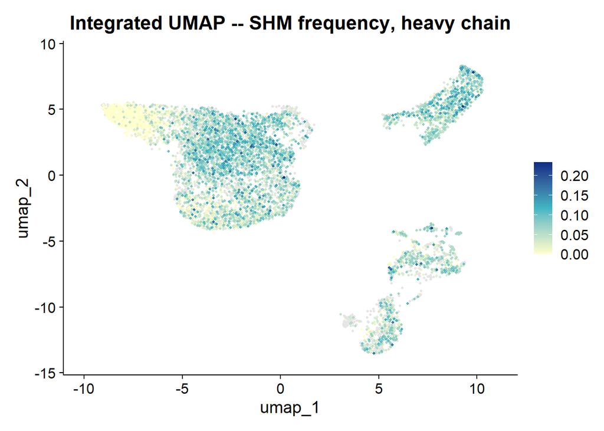

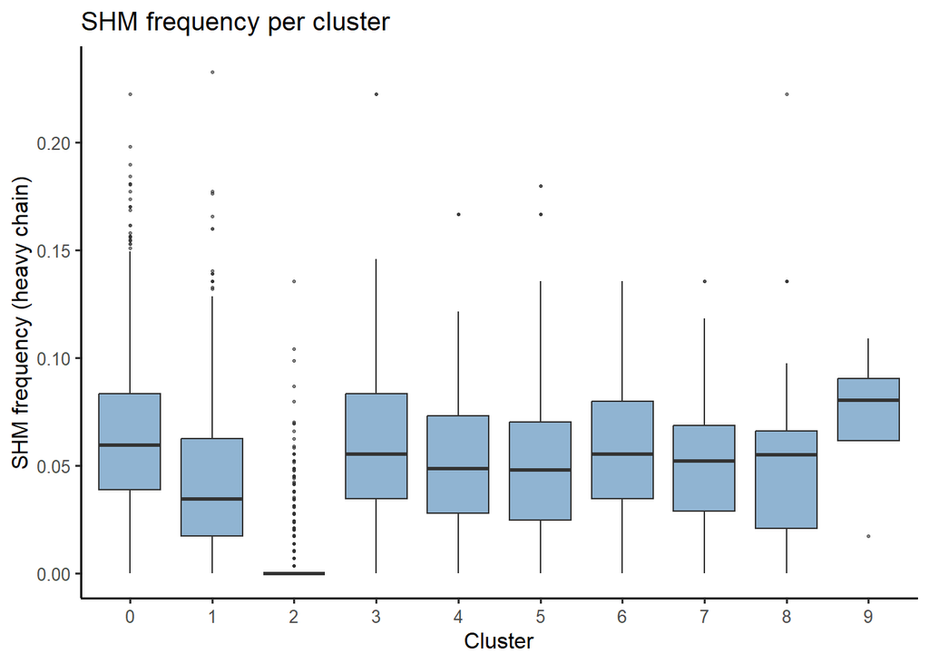

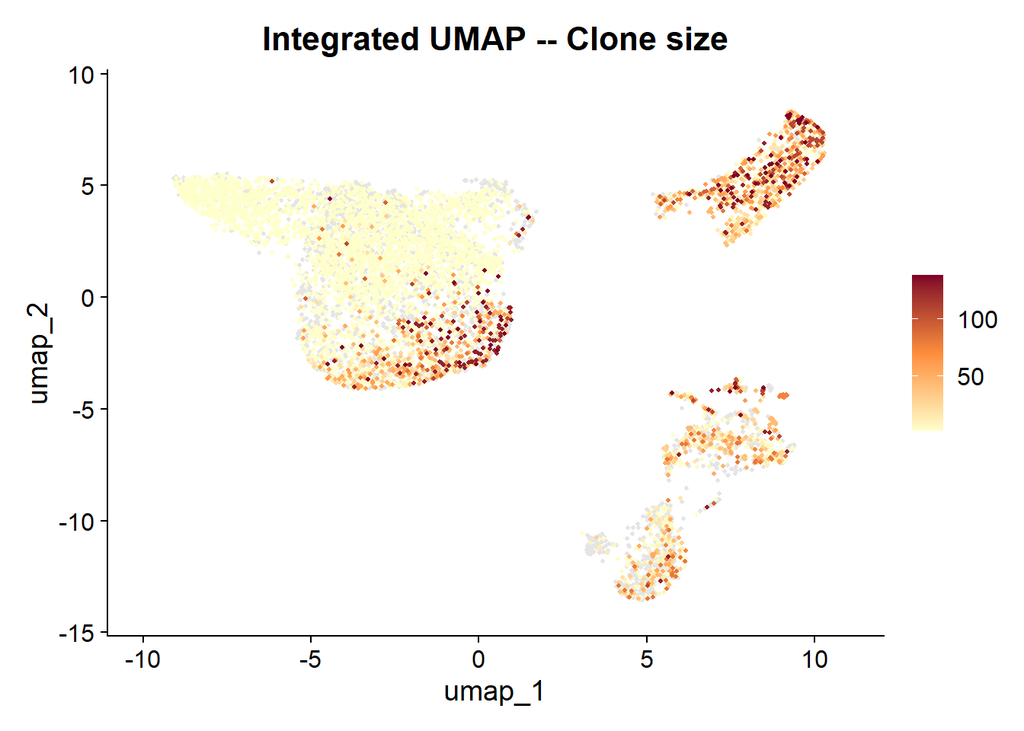

```r
if ("mu_freq_H" %in% colnames(obj@meta.data)) {
  print(
    FeaturePlot(obj, features = "mu_freq_H", reduction = "umap",
                order = TRUE, pt.size = 0.8) +
      scale_color_gradientn(colors = c("#FFFFCC", "#41B6C4", "#0C2C84"),
                            na.value = "grey90") +
      ggtitle("Integrated UMAP -- SHM frequency, heavy chain")
  )

  shm_df_s7 <- obj@meta.data %>%
    dplyr::filter(!is.na(mu_freq_H)) %>%
    dplyr::mutate(seurat_clusters = as.factor(seurat_clusters))
  print(
    ggplot(shm_df_s7, aes(x = seurat_clusters, y = mu_freq_H)) +
      geom_boxplot(outlier.size = 0.5, fill = "steelblue", alpha = 0.6) +
      ylab("SHM frequency (heavy chain)") + xlab("Cluster") +
      theme_classic(base_size = 12) +
      ggtitle("SHM frequency per cluster")
  )

  print(
    FeaturePlot(obj, features = "clone_count", reduction = "umap",
                order = TRUE, pt.size = 0.8) +
      scale_color_gradientn(colors = c("#FFFFCC", "#FD8D3C", "#800026"),
                            na.value = "grey90") +
      ggtitle("Integrated UMAP -- Clone size")
  )
}
```

## 7.9 Clonality per cluster

Cluster 3 stands out as the most clonal in the dataset with a mean clone size of ~3.6 and ~85% of cells in expanded clones. Clusters 4, 5, 7, and 8 show moderate-to-high clonality (mean clone size 2.3-2.8, 74-79% expanded). Cluster 1 also shows substantial clonality (mean ~2.0, 61% expanded). Clusters 0, 2, and 6 show near-zero clonality (mean ~1.0, <15% expanded). Cluster 9 has only 4 cells with BCR data and is uninformative here.

```
##
##
## Table: Clonality per cluster
##
## |seurat_clusters | n_cells| n_clones| clonality| mean_clone_size| max_clone_size| pct_expanded|
## |:---------------|-------:|--------:|---------:|---------------:|--------------:|------------:|
## |0               |    1942|     1792|      0.08|            1.08|              7|        14.37|
## |1               |     934|      458|      0.51|            2.04|             68|        61.03|
## |2               |     668|      647|      0.03|            1.03|              2|         6.29|
## |3               |     665|      187|      0.72|            3.56|             43|        84.51|
## |4               |     276|      119|      0.57|            2.32|             21|        74.28|
## |5               |     326|      127|      0.61|            2.57|             19|        78.83|
## |6               |     291|      284|      0.02|            1.02|              3|         4.47|
## |7               |     210|       87|      0.59|            2.41|             16|        77.14|
## |8               |     130|       46|      0.65|            2.83|             20|        79.23|
## |9               |       4|        4|      0.00|            1.00|              1|         0.00|
```

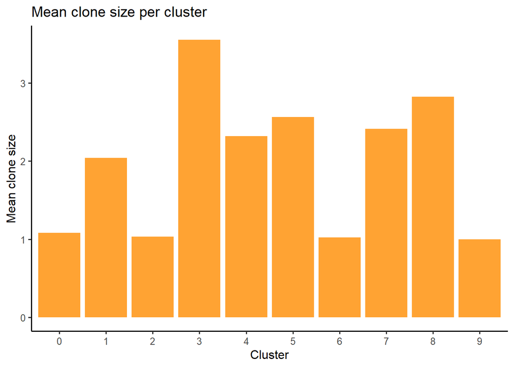

```r
if ("clone_id" %in% colnames(obj@meta.data)) {

  clone_df_s7 <- obj@meta.data %>%
    dplyr::filter(!is.na(clone_id), !is.na(seurat_clusters)) %>%
    dplyr::group_by(seurat_clusters) %>%
    dplyr::summarise(
      n_cells         = dplyr::n(),
      n_clones        = dplyr::n_distinct(clone_id),
      clonality       = 1 - (n_clones / n_cells),
      mean_clone_size = n_cells / n_clones,
      max_clone_size  = max(table(clone_id)),
      pct_expanded    = 100 * mean(table(clone_id)[clone_id] > 1),
      .groups = "drop"
    ) %>%
    dplyr::arrange(as.numeric(as.character(seurat_clusters)))

  print(knitr::kable(clone_df_s7, digits = 2, caption = "Clonality per cluster"))

  print(
    ggplot(clone_df_s7, aes(x = as.factor(seurat_clusters), y = mean_clone_size)) +
      geom_bar(stat = "identity", fill = "darkorange", alpha = 0.8) +
      ylab("Mean clone size") + xlab("Cluster") +
      theme_classic(base_size = 12) +
      ggtitle("Mean clone size per cluster")
  )
}
```

## 7.10 Cell cycle per cluster

Clusters 5 and 8 are the clear proliferating populations: cluster 5 shows near-100% S and G2M phase, and cluster 8 shows ~100% S and G2M.

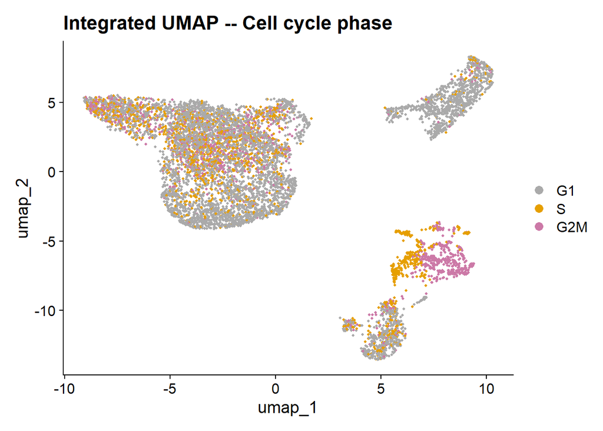

```r
Idents(obj) <- "Phase"
print(
  DimPlot(obj, reduction = "umap", label = FALSE, pt.size = 0.8,
          cols = c("G1" = "#AAAAAA", "S" = "#E69F00", "G2M" = "#CC79A7")) +
    ggtitle("Integrated UMAP -- Cell cycle phase")
)
```

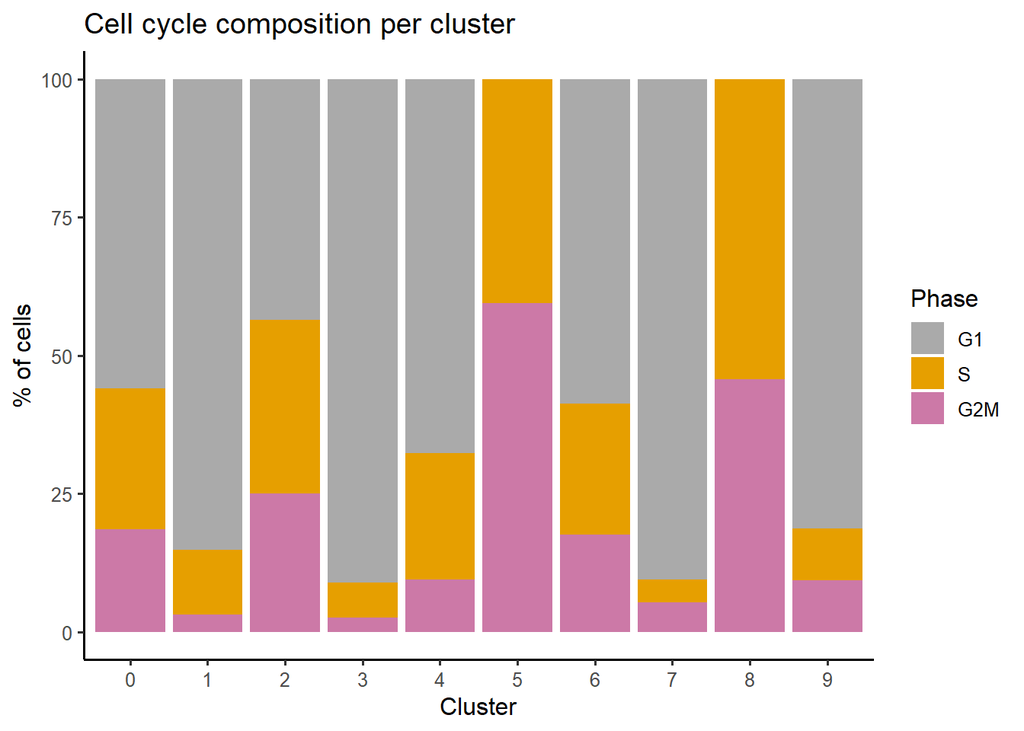

```r
Idents(obj) <- "seurat_clusters"

cc_df_s7 <- obj@meta.data %>%
  dplyr::select(Phase, seurat_clusters) %>%
  dplyr::group_by(seurat_clusters, Phase) %>%
  dplyr::summarise(n = dplyr::n(), .groups = "drop_last") %>%
  dplyr::mutate(pct = 100 * n / sum(n)) %>%
  dplyr::ungroup() %>%
  dplyr::mutate(Phase = factor(Phase, levels = c("G1", "S", "G2M")))

print(
  ggplot(cc_df_s7, aes(x = seurat_clusters, y = pct, fill = Phase)) +
    geom_bar(stat = "identity") +
    scale_fill_manual(values = c("G1" = "#AAAAAA", "S" = "#E69F00", "G2M" = "#CC79A7")) +
    ylab("% of cells") + xlab("Cluster") +
    theme_classic(base_size = 12) +
    ggtitle("Cell cycle composition per cluster")
)
```